# Project: Identify Customer Segments

In this project, you will apply unsupervised learning techniques to identify segments of the population that form the core customer base for a mail-order sales company in Germany. These segments can then be used to direct marketing campaigns towards audiences that will have the highest expected rate of returns. The data that you will use has been provided by our partners at Bertelsmann Arvato Analytics, and represents a real-life data science task.

This notebook will help you complete this task by providing a framework within which you will perform your analysis steps. In each step of the project, you will see some text describing the subtask that you will perform, followed by one or more code cells for you to complete your work. **Feel free to add additional code and markdown cells as you go along so that you can explore everything in precise chunks.** The code cells provided in the base template will outline only the major tasks, and will usually not be enough to cover all of the minor tasks that comprise it.

It should be noted that while there will be precise guidelines on how you should handle certain tasks in the project, there will also be places where an exact specification is not provided. **There will be times in the project where you will need to make and justify your own decisions on how to treat the data.** These are places where there may not be only one way to handle the data. In real-life tasks, there may be many valid ways to approach an analysis task. One of the most important things you can do is clearly document your approach so that other scientists can understand the decisions you've made.

At the end of most sections, there will be a Markdown cell labeled **Discussion**. In these cells, you will report your findings for the completed section, as well as document the decisions that you made in your approach to each subtask. **Your project will be evaluated not just on the code used to complete the tasks outlined, but also your communication about your observations and conclusions at each stage.**

```python
# import libraries here; add more as necessary
import numpy as np
import pandas as pd
import matplotlib.pyplot as plt
import seaborn as sns
from sklearn.preprocessing import StandardScaler, Imputer
from sklearn.decomposition import PCA
from sklearn.cluster import KMeans
import time

# magic word for producing visualizations in notebook
%matplotlib inline
```

### Step 0: Load the Data

There are four files associated with this project (not including this one):

- `Udacity_AZDIAS_Subset.csv`: Demographics data for the general population of Germany; 891211 persons (rows) x 85 features (columns).
- `Udacity_CUSTOMERS_Subset.csv`: Demographics data for customers of a mail-order company; 191652 persons (rows) x 85 features (columns).
- `Data_Dictionary.md`: Detailed information file about the features in the provided datasets.
- `AZDIAS_Feature_Summary.csv`: Summary of feature attributes for demographics data; 85 features (rows) x 4 columns

Each row of the demographics files represents a single person, but also includes information outside of individuals, including information about their household, building, and neighborhood. You will use this information to cluster the general population into groups with similar demographic properties. Then, you will see how the people in the customers dataset fit into those created clusters. The hope here is that certain clusters are over-represented in the customers data, as compared to the general population; those over-represented clusters will be assumed to be part of the core userbase. This information can then be used for further applications, such as targeting for a marketing campaign.

To start off with, load in the demographics data for the general population into a pandas DataFrame, and do the same for the feature attributes summary. Note for all of the `.csv` data files in this project: they're semicolon (`;`) delimited, so you'll need an additional argument in your [`read_csv()`](https://pandas.pydata.org/pandas-docs/stable/generated/pandas.read_csv.html) call to read in the data properly. Also, considering the size of the main dataset, it may take some time for it to load completely.

Once the dataset is loaded, it's recommended that you take a little bit of time just browsing the general structure of the dataset and feature summary file. You'll be getting deep into the innards of the cleaning in the first major step of the project, so gaining some general familiarity can help you get your bearings.

```python
# Load in the general demographics data.
azdias = pd.read_csv('Udacity_AZDIAS_Subset.csv', sep=';')

# Load in the feature summary file.
feat_info = pd.read_csv('AZDIAS_Feature_Summary.csv', sep=';')

# Load in the data dictionary file.
data_dictionary = open("Data_Dictionary.md")
```

**Data dictionary file:**

```python
# Check the structure of the data after it's loaded (e.g. print the number ofa
# rows and columns, print the first few rows).

# Print data dictionary file
print(data_dictionary.read())
```

```
# Data Dictionary for Identify Customer Segments Data

## Introduction

The data for this project consist of two files:

- Udacity_AZDIAS_Subset.csv: demographics data for the general population of
      Germany; 891211 persons (rows) x 85 features (columns)
- Udacity_CUSTOMERS_Subset.csv: demographics data for customers of a mail-order
      company; 191652 persons (rows) x 85 features (columns)

The columns in the general demographics file and customers data file are the
same. This file documents the features that appear in the data files, sorted in
order of appearance. Sections of this file is based on the level of measurement
of each feature. The file "AZDIAS_Feature_Summary.csv" contains a summary of
feature attributes, including information level, data type, and codes for
missing or unknown values.

### Table of Contents

 1. Person-level features
 2. Household-level features
 3. Building-level features
 4. RR4 micro-cell features
 5. RR3 micro-cell features
 6. Postcode-level features
 7. RR1 neighborhood features
 8. PLZ8 macro-cell features
 9. Community-level features

-----

## 1. Person-level features

### 1.1. AGER_TYP
Best-ager typology
- -1: unknown
-  0: no classification possible
-  1: passive elderly
-  2: cultural elderly
```

[output cut: 774 more lines]

```
-  5:  20,001 to  50,000 inhabitants
-  6:  50,001 to 100,000 inhabitants
-  7: 100,001 to 300,000 inhabitants
-  8: 300,001 to 700,000 inhabitants
-  9: > 700,000  inhabitants

### 9.3. RELAT_AB
Share of unemployment relative to county in which community is contained
- -1: unknown
-  1: very low
-  2: low
-  3: average
-  4: high
-  5: very high
-  9: unknown
```

**AZDIAS demographics dataset:**

```python
# Print the first 15 rows in the azdias dataframe
azdias.head(15)
```

|  | AGER_TYP | ALTERSKATEGORIE_GROB | ANREDE_KZ | CJT_GESAMTTYP | FINANZ_MINIMALIST | FINANZ_SPARER | FINANZ_VORSORGER | FINANZ_ANLEGER | FINANZ_UNAUFFAELLIGER | FINANZ_HAUSBAUER | ... | PLZ8_ANTG1 | PLZ8_ANTG2 | PLZ8_ANTG3 | PLZ8_ANTG4 | PLZ8_BAUMAX | PLZ8_HHZ | PLZ8_GBZ | ARBEIT | ORTSGR_KLS9 | RELAT_AB |
| --- | --- | --- | --- | --- | --- | --- | --- | --- | --- | --- | --- | --- | --- | --- | --- | --- | --- | --- | --- | --- | --- |
| 0 | -1 | 2 | 1 | 2.0 | 3 | 4 | 3 | 5 | 5 | 3 | ... | NaN | NaN | NaN | NaN | NaN | NaN | NaN | NaN | NaN | NaN |
| 1 | -1 | 1 | 2 | 5.0 | 1 | 5 | 2 | 5 | 4 | 5 | ... | 2.0 | 3.0 | 2.0 | 1.0 | 1.0 | 5.0 | 4.0 | 3.0 | 5.0 | 4.0 |
| 2 | -1 | 3 | 2 | 3.0 | 1 | 4 | 1 | 2 | 3 | 5 | ... | 3.0 | 3.0 | 1.0 | 0.0 | 1.0 | 4.0 | 4.0 | 3.0 | 5.0 | 2.0 |
| 3 | 2 | 4 | 2 | 2.0 | 4 | 2 | 5 | 2 | 1 | 2 | ... | 2.0 | 2.0 | 2.0 | 0.0 | 1.0 | 3.0 | 4.0 | 2.0 | 3.0 | 3.0 |
| 4 | -1 | 3 | 1 | 5.0 | 4 | 3 | 4 | 1 | 3 | 2 | ... | 2.0 | 4.0 | 2.0 | 1.0 | 2.0 | 3.0 | 3.0 | 4.0 | 6.0 | 5.0 |
| 5 | 3 | 1 | 2 | 2.0 | 3 | 1 | 5 | 2 | 2 | 5 | ... | 2.0 | 3.0 | 1.0 | 1.0 | 1.0 | 5.0 | 5.0 | 2.0 | 3.0 | 3.0 |
| 6 | -1 | 2 | 2 | 5.0 | 1 | 5 | 1 | 5 | 4 | 3 | ... | 3.0 | 3.0 | 1.0 | 0.0 | 1.0 | 5.0 | 5.0 | 4.0 | 6.0 | 3.0 |
| 7 | -1 | 1 | 1 | 3.0 | 3 | 3 | 4 | 1 | 3 | 2 | ... | 3.0 | 3.0 | 1.0 | 0.0 | 1.0 | 4.0 | 4.0 | 2.0 | 5.0 | 2.0 |
| 8 | -1 | 3 | 1 | 3.0 | 4 | 4 | 2 | 4 | 2 | 2 | ... | 2.0 | 3.0 | 2.0 | 1.0 | 1.0 | 3.0 | 3.0 | 2.0 | 4.0 | 3.0 |
| 9 | -1 | 3 | 2 | 4.0 | 2 | 4 | 2 | 3 | 5 | 4 | ... | 2.0 | 3.0 | 2.0 | 1.0 | 1.0 | 3.0 | 3.0 | 2.0 | 3.0 | 1.0 |
| 10 | 0 | 3 | 2 | 1.0 | 2 | 2 | 5 | 3 | 1 | 5 | ... | 2.0 | 4.0 | 2.0 | 0.0 | 2.0 | 3.0 | 3.0 | 4.0 | 6.0 | 5.0 |
| 11 | -1 | 2 | 1 | 6.0 | 3 | 4 | 3 | 5 | 5 | 3 | ... | NaN | NaN | NaN | NaN | NaN | NaN | NaN | NaN | NaN | NaN |
| 12 | -1 | 3 | 1 | 6.0 | 5 | 3 | 4 | 2 | 4 | 1 | ... | 3.0 | 3.0 | 1.0 | 0.0 | 1.0 | 5.0 | 5.0 | 3.0 | 6.0 | 4.0 |
| 13 | -1 | 1 | 2 | 5.0 | 1 | 4 | 3 | 5 | 5 | 2 | ... | 2.0 | 1.0 | 1.0 | 1.0 | 1.0 | 3.0 | 3.0 | 3.0 | 6.0 | 4.0 |
| 14 | -1 | 3 | 1 | 6.0 | 3 | 4 | 3 | 5 | 5 | 3 | ... | NaN | NaN | NaN | NaN | NaN | NaN | NaN | NaN | NaN | NaN |

15 rows × 85 columns

```python
# Print number of rows and columns in dataframe
print('Number of rows (persons): {}'.format(azdias.shape[0]))
print('Number of columns (features): {}'.format(azdias.shape[1]))
```

```
Number of rows (persons): 891221
Number of columns (features): 85
```

**The azdias demographics dataframe has 891 221 rows (persons/samples) and 85 columns (features). There are some NaN (not a number) values present, which might be a reperesentation of missing values/data. There doesn't seem to be any unique identifier, only the index number for each row, so we can't check if there are any duplicates in the dataset. Tha data is numeric and in small values but the column names don't explain much of what it means.**

```python
# Print dataframe summary
azdias.info()
```

```
<class 'pandas.core.frame.DataFrame'>
RangeIndex: 891221 entries, 0 to 891220
Data columns (total 85 columns):
AGER_TYP                 891221 non-null int64
ALTERSKATEGORIE_GROB     891221 non-null int64
ANREDE_KZ                891221 non-null int64
CJT_GESAMTTYP            886367 non-null float64
FINANZ_MINIMALIST        891221 non-null int64
FINANZ_SPARER            891221 non-null int64
FINANZ_VORSORGER         891221 non-null int64
FINANZ_ANLEGER           891221 non-null int64
FINANZ_UNAUFFAELLIGER    891221 non-null int64
FINANZ_HAUSBAUER         891221 non-null int64
FINANZTYP                891221 non-null int64
GEBURTSJAHR              891221 non-null int64
GFK_URLAUBERTYP          886367 non-null float64
GREEN_AVANTGARDE         891221 non-null int64
HEALTH_TYP               891221 non-null int64
LP_LEBENSPHASE_FEIN      886367 non-null float64
LP_LEBENSPHASE_GROB      886367 non-null float64
LP_FAMILIE_FEIN          886367 non-null float64
LP_FAMILIE_GROB          886367 non-null float64
LP_STATUS_FEIN           886367 non-null float64
LP_STATUS_GROB           886367 non-null float64
NATIONALITAET_KZ         891221 non-null int64
PRAEGENDE_JUGENDJAHRE    891221 non-null int64
RETOURTYP_BK_S           886367 non-null float64
SEMIO_SOZ                891221 non-null int64
SEMIO_FAM                891221 non-null int64
SEMIO_REL                891221 non-null int64
SEMIO_MAT                891221 non-null int64
SEMIO_VERT               891221 non-null int64
SEMIO_LUST               891221 non-null int64
SEMIO_ERL                891221 non-null int64
SEMIO_KULT               891221 non-null int64
SEMIO_RAT                891221 non-null int64
SEMIO_KRIT               891221 non-null int64
SEMIO_DOM                891221 non-null int64
SEMIO_KAEM               891221 non-null int64
SEMIO_PFLICHT            891221 non-null int64
```

[output cut: 35 more lines]

```
ONLINE_AFFINITAET        886367 non-null float64
REGIOTYP                 770025 non-null float64
KBA13_ANZAHL_PKW         785421 non-null float64
PLZ8_ANTG1               774706 non-null float64
PLZ8_ANTG2               774706 non-null float64
PLZ8_ANTG3               774706 non-null float64
PLZ8_ANTG4               774706 non-null float64
PLZ8_BAUMAX              774706 non-null float64
PLZ8_HHZ                 774706 non-null float64
PLZ8_GBZ                 774706 non-null float64
ARBEIT                   794005 non-null float64
ORTSGR_KLS9              794005 non-null float64
RELAT_AB                 794005 non-null float64
dtypes: float64(49), int64(32), object(4)
memory usage: 578.0+ MB
```

**The summary above shows information on all the columns - their names, counts (excluding NaNs) and data types. We can see from the different column counts that there appears to be missing values in the dataset.**

```python
# Print number of missing values (NaN) in each column, show all columns
with pd.option_context("display.max_rows", 85):
    print(azdias.isnull().sum())
```

```
AGER_TYP                      0
ALTERSKATEGORIE_GROB          0
ANREDE_KZ                     0
CJT_GESAMTTYP              4854
FINANZ_MINIMALIST             0
FINANZ_SPARER                 0
FINANZ_VORSORGER              0
FINANZ_ANLEGER                0
FINANZ_UNAUFFAELLIGER         0
FINANZ_HAUSBAUER              0
FINANZTYP                     0
GEBURTSJAHR                   0
GFK_URLAUBERTYP            4854
GREEN_AVANTGARDE              0
HEALTH_TYP                    0
LP_LEBENSPHASE_FEIN        4854
LP_LEBENSPHASE_GROB        4854
LP_FAMILIE_FEIN            4854
LP_FAMILIE_GROB            4854
LP_STATUS_FEIN             4854
LP_STATUS_GROB             4854
NATIONALITAET_KZ              0
PRAEGENDE_JUGENDJAHRE         0
RETOURTYP_BK_S             4854
SEMIO_SOZ                     0
SEMIO_FAM                     0
SEMIO_REL                     0
SEMIO_MAT                     0
SEMIO_VERT                    0
SEMIO_LUST                    0
SEMIO_ERL                     0
SEMIO_KULT                    0
SEMIO_RAT                     0
SEMIO_KRIT                    0
SEMIO_DOM                     0
SEMIO_KAEM                    0
SEMIO_PFLICHT                 0
SEMIO_TRADV                   0
SHOPPER_TYP                   0
SOHO_KZ                   73499
```

[output cut: 31 more lines]

```
MOBI_REGIO               133324
ONLINE_AFFINITAET          4854
REGIOTYP                 121196
KBA13_ANZAHL_PKW         105800
PLZ8_ANTG1               116515
PLZ8_ANTG2               116515
PLZ8_ANTG3               116515
PLZ8_ANTG4               116515
PLZ8_BAUMAX              116515
PLZ8_HHZ                 116515
PLZ8_GBZ                 116515
ARBEIT                    97216
ORTSGR_KLS9               97216
RELAT_AB                  97216
dtype: int64
```

**The number of missing values (NaN) per column is shown above. A lot of columns have the same number of missing values which might indicate that those columns only apply to a subset of the data. This probably means that no data is actually missing, some rows simply should not have data in those columns.**

**AZDIAS feature summary dataset:**

```python
# Print dataframe, show all columns
with pd.option_context("display.max_rows", 85):
    display(feat_info)
```

|  | attribute | information_level | type | missing_or_unknown |
| --- | --- | --- | --- | --- |
| 0 | AGER_TYP | person | categorical | [-1,0] |
| 1 | ALTERSKATEGORIE_GROB | person | ordinal | [-1,0,9] |
| 2 | ANREDE_KZ | person | categorical | [-1,0] |
| 3 | CJT_GESAMTTYP | person | categorical | [0] |
| 4 | FINANZ_MINIMALIST | person | ordinal | [-1] |
| 5 | FINANZ_SPARER | person | ordinal | [-1] |
| 6 | FINANZ_VORSORGER | person | ordinal | [-1] |
| 7 | FINANZ_ANLEGER | person | ordinal | [-1] |
| 8 | FINANZ_UNAUFFAELLIGER | person | ordinal | [-1] |
| 9 | FINANZ_HAUSBAUER | person | ordinal | [-1] |
| 10 | FINANZTYP | person | categorical | [-1] |
| 11 | GEBURTSJAHR | person | numeric | [0] |
| 12 | GFK_URLAUBERTYP | person | categorical | [] |
| 13 | GREEN_AVANTGARDE | person | categorical | [] |
| 14 | HEALTH_TYP | person | ordinal | [-1,0] |
| 15 | LP_LEBENSPHASE_FEIN | person | mixed | [0] |
| 16 | LP_LEBENSPHASE_GROB | person | mixed | [0] |
| 17 | LP_FAMILIE_FEIN | person | categorical | [0] |
| 18 | LP_FAMILIE_GROB | person | categorical | [0] |
| 19 | LP_STATUS_FEIN | person | categorical | [0] |
| 20 | LP_STATUS_GROB | person | categorical | [0] |
| 21 | NATIONALITAET_KZ | person | categorical | [-1,0] |
| 22 | PRAEGENDE_JUGENDJAHRE | person | mixed | [-1,0] |
| 23 | RETOURTYP_BK_S | person | ordinal | [0] |
| 24 | SEMIO_SOZ | person | ordinal | [-1,9] |
| 25 | SEMIO_FAM | person | ordinal | [-1,9] |
| 26 | SEMIO_REL | person | ordinal | [-1,9] |
| 27 | SEMIO_MAT | person | ordinal | [-1,9] |
| 28 | SEMIO_VERT | person | ordinal | [-1,9] |
| 29 | SEMIO_LUST | person | ordinal | [-1,9] |

[output cut: 55 more lines]

```python
# Print number of rows and columns in dataframe
print('Number of rows (features): {}'.format(feat_info.shape[0]))
print('Number of columns: {}'.format(feat_info.shape[1]))
```

```
Number of rows (features): 85
Number of columns: 4
```

**The feature summary dataframe has 85 rows (features) and 4 columns with information on these features. The columns seem to be divided into different categories based on the *information_level* column. The other columns appear to show the data types and what seems to be the codes used for missing or unknown values in each column, this is also confirmed by the information found in the *Data_Dictionary.md* file.**

```python
# Print value names and counts for column information_level
feat_info.information_level.value_counts()
```

```
person            43
macrocell_plz8     8
household          7
building           7
microcell_rr3      6
region_rr1         5
community          3
microcell_rr4      3
postcode           3
Name: information_level, dtype: int64
```

**Above we can see the names of the information level categories and how many columns belong to each. Most of the columns are person level features.**

> **Tip**: Add additional cells to keep everything in reasonably-sized chunks! Keyboard shortcut `esc --> a` (press escape to enter command mode, then press the 'A' key) adds a new cell before the active cell, and `esc --> b` adds a new cell after the active cell. If you need to convert an active cell to a markdown cell, use `esc --> m` and to convert to a code cell, use `esc --> y`.

## Step 1: Preprocessing

### Step 1.1: Assess Missing Data

The feature summary file contains a summary of properties for each demographics data column. You will use this file to help you make cleaning decisions during this stage of the project. First of all, you should assess the demographics data in terms of missing data. Pay attention to the following points as you perform your analysis, and take notes on what you observe. Make sure that you fill in the **Discussion** cell with your findings and decisions at the end of each step that has one!

#### Step 1.1.1: Convert Missing Value Codes to NaNs

The fourth column of the feature attributes summary (loaded in above as `feat_info`) documents the codes from the data dictionary that indicate missing or unknown data. While the file encodes this as a list (e.g. `[-1,0]`), this will get read in as a string object. You'll need to do a little bit of parsing to make use of it to identify and clean the data. Convert data that matches a 'missing' or 'unknown' value code into a numpy NaN value. You might want to see how much data takes on a 'missing' or 'unknown' code, and how much data is naturally missing, as a point of interest.

**As one more reminder, you are encouraged to add additional cells to break up your analysis into manageable chunks.**

```python
# Identify missing or unknown data values and convert them to NaNs.

# Store and print total number of naturally missing values (NaN) in dataset
natural_nans = azdias.isnull().sum().sum()
print('Total number of naturally missing values (NaN) in dataset: {}'.format(natural_nans))
```

```
Total number of naturally missing values (NaN) in dataset: 4896838
```

**We already took a look at the number of missing values (NaN) in each column in the azdias demographics dataset and the possible reason for that in the previous step. Above shows the total number of naturally missing values in the entire dataset. That is, the values missing in the data before doing any data cleaning.**

```python
# Create copy of dataframe, I don't want to make changes in the original
az_clean = azdias.copy()
```

```python
# Replace codes for missing data from feat_info with NaN values
for i in range(len(feat_info)):
    missing_or_unknown = feat_info.iloc[i]['missing_or_unknown'].strip('[, ]').split(',')
    missing_or_unknown = [int(value) if (value!='X' and value!='XX' and value!='') else
                          value for value in missing_or_unknown]
    if missing_or_unknown != ['']:
        az_clean = az_clean.replace({feat_info.iloc[i]['attribute']: missing_or_unknown}, np.nan)
```

```python
# azdias dataframe after converting values to NaNs
az_clean
```

|  | AGER_TYP | ALTERSKATEGORIE_GROB | ANREDE_KZ | CJT_GESAMTTYP | FINANZ_MINIMALIST | FINANZ_SPARER | FINANZ_VORSORGER | FINANZ_ANLEGER | FINANZ_UNAUFFAELLIGER | FINANZ_HAUSBAUER | ... | PLZ8_ANTG1 | PLZ8_ANTG2 | PLZ8_ANTG3 | PLZ8_ANTG4 | PLZ8_BAUMAX | PLZ8_HHZ | PLZ8_GBZ | ARBEIT | ORTSGR_KLS9 | RELAT_AB |
| --- | --- | --- | --- | --- | --- | --- | --- | --- | --- | --- | --- | --- | --- | --- | --- | --- | --- | --- | --- | --- | --- |
| 0 | NaN | 2.0 | 1 | 2.0 | 3 | 4 | 3 | 5 | 5 | 3 | ... | NaN | NaN | NaN | NaN | NaN | NaN | NaN | NaN | NaN | NaN |
| 1 | NaN | 1.0 | 2 | 5.0 | 1 | 5 | 2 | 5 | 4 | 5 | ... | 2.0 | 3.0 | 2.0 | 1.0 | 1.0 | 5.0 | 4.0 | 3.0 | 5.0 | 4.0 |
| 2 | NaN | 3.0 | 2 | 3.0 | 1 | 4 | 1 | 2 | 3 | 5 | ... | 3.0 | 3.0 | 1.0 | 0.0 | 1.0 | 4.0 | 4.0 | 3.0 | 5.0 | 2.0 |
| 3 | 2.0 | 4.0 | 2 | 2.0 | 4 | 2 | 5 | 2 | 1 | 2 | ... | 2.0 | 2.0 | 2.0 | 0.0 | 1.0 | 3.0 | 4.0 | 2.0 | 3.0 | 3.0 |
| 4 | NaN | 3.0 | 1 | 5.0 | 4 | 3 | 4 | 1 | 3 | 2 | ... | 2.0 | 4.0 | 2.0 | 1.0 | 2.0 | 3.0 | 3.0 | 4.0 | 6.0 | 5.0 |
| 5 | 3.0 | 1.0 | 2 | 2.0 | 3 | 1 | 5 | 2 | 2 | 5 | ... | 2.0 | 3.0 | 1.0 | 1.0 | 1.0 | 5.0 | 5.0 | 2.0 | 3.0 | 3.0 |
| 6 | NaN | 2.0 | 2 | 5.0 | 1 | 5 | 1 | 5 | 4 | 3 | ... | 3.0 | 3.0 | 1.0 | 0.0 | 1.0 | 5.0 | 5.0 | 4.0 | 6.0 | 3.0 |
| 7 | NaN | 1.0 | 1 | 3.0 | 3 | 3 | 4 | 1 | 3 | 2 | ... | 3.0 | 3.0 | 1.0 | 0.0 | 1.0 | 4.0 | 4.0 | 2.0 | 5.0 | 2.0 |
| 8 | NaN | 3.0 | 1 | 3.0 | 4 | 4 | 2 | 4 | 2 | 2 | ... | 2.0 | 3.0 | 2.0 | 1.0 | 1.0 | 3.0 | 3.0 | 2.0 | 4.0 | 3.0 |
| 9 | NaN | 3.0 | 2 | 4.0 | 2 | 4 | 2 | 3 | 5 | 4 | ... | 2.0 | 3.0 | 2.0 | 1.0 | 1.0 | 3.0 | 3.0 | 2.0 | 3.0 | 1.0 |
| 10 | NaN | 3.0 | 2 | 1.0 | 2 | 2 | 5 | 3 | 1 | 5 | ... | 2.0 | 4.0 | 2.0 | 0.0 | 2.0 | 3.0 | 3.0 | 4.0 | 6.0 | 5.0 |
| 11 | NaN | 2.0 | 1 | 6.0 | 3 | 4 | 3 | 5 | 5 | 3 | ... | NaN | NaN | NaN | NaN | NaN | NaN | NaN | NaN | NaN | NaN |
| 12 | NaN | 3.0 | 1 | 6.0 | 5 | 3 | 4 | 2 | 4 | 1 | ... | 3.0 | 3.0 | 1.0 | 0.0 | 1.0 | 5.0 | 5.0 | 3.0 | 6.0 | 4.0 |
| 13 | NaN | 1.0 | 2 | 5.0 | 1 | 4 | 3 | 5 | 5 | 2 | ... | 2.0 | 1.0 | 1.0 | 1.0 | 1.0 | 3.0 | 3.0 | 3.0 | 6.0 | 4.0 |
| 14 | NaN | 3.0 | 1 | 6.0 | 3 | 4 | 3 | 5 | 5 | 3 | ... | NaN | NaN | NaN | NaN | NaN | NaN | NaN | NaN | NaN | NaN |
| 15 | 1.0 | 4.0 | 2 | 4.0 | 4 | 1 | 5 | 1 | 1 | 4 | ... | NaN | NaN | NaN | NaN | NaN | NaN | NaN | 4.0 | 8.0 | 5.0 |
| 16 | NaN | 1.0 | 2 | 1.0 | 4 | 3 | 1 | 4 | 5 | 1 | ... | 3.0 | 3.0 | 1.0 | 0.0 | 1.0 | 3.0 | 4.0 | 1.0 | 2.0 | 1.0 |
| 17 | NaN | 2.0 | 1 | 6.0 | 3 | 4 | 3 | 5 | 5 | 3 | ... | NaN | NaN | NaN | NaN | NaN | NaN | NaN | NaN | NaN | NaN |
| 18 | NaN | 2.0 | 2 | 6.0 | 2 | 4 | 1 | 5 | 4 | 1 | ... | 2.0 | 3.0 | 2.0 | 1.0 | 1.0 | 3.0 | 3.0 | 3.0 | 4.0 | 3.0 |
| 19 | NaN | 3.0 | 1 | 3.0 | 5 | 2 | 3 | 1 | 3 | 1 | ... | 2.0 | 4.0 | 2.0 | 1.0 | 2.0 | 5.0 | 4.0 | 4.0 | 6.0 | 3.0 |
| 20 | NaN | 2.0 | 2 | 4.0 | 4 | 3 | 1 | 4 | 5 | 1 | ... | NaN | NaN | NaN | NaN | NaN | NaN | NaN | 3.0 | 4.0 | 1.0 |
| 21 | NaN | 2.0 | 1 | 3.0 | 3 | 4 | 1 | 2 | 5 | 1 | ... | 1.0 | 4.0 | 3.0 | 2.0 | 4.0 | 4.0 | 3.0 | 5.0 | 7.0 | 5.0 |
| 22 | NaN | 1.0 | 1 | 4.0 | 1 | 5 | 3 | 5 | 5 | 5 | ... | 2.0 | 4.0 | 2.0 | 1.0 | 2.0 | 4.0 | 3.0 | 4.0 | 5.0 | 5.0 |
| 23 | NaN | 3.0 | 1 | 3.0 | 5 | 3 | 3 | 2 | 2 | 1 | ... | NaN | NaN | NaN | NaN | NaN | NaN | NaN | 3.0 | 6.0 | 2.0 |
| 24 | NaN | 3.0 | 2 | 6.0 | 3 | 4 | 3 | 5 | 5 | 3 | ... | NaN | NaN | NaN | NaN | NaN | NaN | NaN | NaN | NaN | NaN |
| 25 | NaN | 1.0 | 1 | 3.0 | 3 | 5 | 3 | 5 | 4 | 3 | ... | 2.0 | 2.0 | 0.0 | 0.0 | 1.0 | 4.0 | 5.0 | 3.0 | 2.0 | 5.0 |
| 26 | NaN | 3.0 | 1 | 3.0 | 5 | 2 | 4 | 2 | 3 | 1 | ... | NaN | NaN | NaN | NaN | NaN | NaN | NaN | 4.0 | 3.0 | 5.0 |
| 27 | NaN | 3.0 | 1 | 4.0 | 3 | 3 | 4 | 1 | 2 | 2 | ... | 2.0 | 3.0 | 3.0 | 2.0 | 4.0 | 5.0 | 3.0 | 4.0 | 7.0 | 5.0 |
| 28 | NaN | 3.0 | 1 | 2.0 | 3 | 2 | 4 | 3 | 3 | 2 | ... | 3.0 | 3.0 | 1.0 | 0.0 | 1.0 | 5.0 | 5.0 | 3.0 | 4.0 | 1.0 |
| 29 | 2.0 | 4.0 | 2 | 1.0 | 5 | 1 | 5 | 2 | 1 | 3 | ... | 3.0 | 2.0 | 2.0 | 0.0 | 1.0 | 3.0 | 4.0 | 2.0 | 4.0 | 3.0 |
| ... | ... | ... | ... | ... | ... | ... | ... | ... | ... | ... | ... | ... | ... | ... | ... | ... | ... | ... | ... | ... | ... |
| 891191 | 1.0 | 4.0 | 2 | 1.0 | 4 | 1 | 5 | 1 | 1 | 4 | ... | 3.0 | 3.0 | 1.0 | 0.0 | 1.0 | 4.0 | 5.0 | 1.0 | 3.0 | 1.0 |
| 891192 | NaN | 1.0 | 2 | 3.0 | 1 | 5 | 2 | 5 | 3 | 5 | ... | 4.0 | 2.0 | 1.0 | 0.0 | 1.0 | 3.0 | 3.0 | 3.0 | 5.0 | 1.0 |
| 891193 | 2.0 | 4.0 | 1 | 3.0 | 4 | 1 | 5 | 1 | 2 | 5 | ... | 2.0 | 4.0 | 1.0 | 0.0 | 2.0 | 2.0 | 2.0 | 4.0 | 6.0 | 4.0 |
| 891194 | NaN | 3.0 | 1 | 4.0 | 4 | 3 | 4 | 2 | 3 | 1 | ... | 3.0 | 2.0 | 2.0 | 0.0 | 1.0 | 4.0 | 4.0 | 4.0 | 8.0 | 5.0 |
| 891195 | 2.0 | 4.0 | 2 | 6.0 | 3 | 1 | 5 | 1 | 1 | 5 | ... | 2.0 | 3.0 | 2.0 | 1.0 | 1.0 | 4.0 | 3.0 | 4.0 | 7.0 | 5.0 |
| 891196 | NaN | 2.0 | 2 | 6.0 | 1 | 5 | 2 | 5 | 4 | 3 | ... | 2.0 | 3.0 | 2.0 | 1.0 | 1.0 | 3.0 | 3.0 | 3.0 | 4.0 | 5.0 |
| 891197 | NaN | 3.0 | 2 | 1.0 | 3 | 2 | 4 | 1 | 3 | 3 | ... | 2.0 | 3.0 | 2.0 | 1.0 | 1.0 | 4.0 | 4.0 | 3.0 | 9.0 | 5.0 |
| 891198 | NaN | 3.0 | 1 | 5.0 | 2 | 5 | 3 | 4 | 5 | 3 | ... | 4.0 | 2.0 | 1.0 | 0.0 | 1.0 | 4.0 | 5.0 | 3.0 | 9.0 | 5.0 |
| 891199 | NaN | 2.0 | 1 | 3.0 | 2 | 5 | 2 | 3 | 3 | 4 | ... | 1.0 | 4.0 | 3.0 | 2.0 | 5.0 | 5.0 | 3.0 | 3.0 | 7.0 | 3.0 |
| 891200 | NaN | 1.0 | 2 | 3.0 | 1 | 5 | 3 | 5 | 5 | 5 | ... | 1.0 | 4.0 | 2.0 | 1.0 | 2.0 | 3.0 | 3.0 | 4.0 | 6.0 | 5.0 |
| 891201 | NaN | 3.0 | 1 | 3.0 | 4 | 2 | 3 | 2 | 2 | 3 | ... | 1.0 | 4.0 | 3.0 | 1.0 | 3.0 | 4.0 | 3.0 | 3.0 | 7.0 | 5.0 |
| 891202 | NaN | 2.0 | 2 | 5.0 | 1 | 4 | 1 | 2 | 5 | 4 | ... | 1.0 | 4.0 | 3.0 | 2.0 | 5.0 | 4.0 | 2.0 | 4.0 | 8.0 | 5.0 |
| 891203 | NaN | 4.0 | 2 | 1.0 | 4 | 1 | 5 | 1 | 3 | 4 | ... | 2.0 | 3.0 | 2.0 | 1.0 | 1.0 | 3.0 | 3.0 | 4.0 | 8.0 | 5.0 |
| 891204 | NaN | 3.0 | 1 | 5.0 | 4 | 3 | 4 | 4 | 2 | 1 | ... | 2.0 | 3.0 | 1.0 | 0.0 | 1.0 | 3.0 | 4.0 | 4.0 | 7.0 | 3.0 |
| 891205 | 1.0 | 4.0 | 1 | 2.0 | 4 | 2 | 4 | 3 | 3 | 4 | ... | 1.0 | 4.0 | 3.0 | 1.0 | 3.0 | 3.0 | 2.0 | 3.0 | 7.0 | 5.0 |
| 891206 | NaN | 1.0 | 2 | 4.0 | 3 | 4 | 2 | 4 | 4 | 2 | ... | 3.0 | 2.0 | 1.0 | 0.0 | 1.0 | 4.0 | 5.0 | 3.0 | 4.0 | 3.0 |
| 891207 | 1.0 | 3.0 | 2 | 1.0 | 5 | 1 | 5 | 1 | 2 | 4 | ... | 2.0 | 3.0 | 2.0 | 2.0 | 4.0 | 4.0 | 2.0 | 1.0 | 5.0 | 1.0 |
| 891208 | NaN | 4.0 | 1 | 2.0 | 5 | 2 | 4 | 2 | 3 | 1 | ... | 3.0 | 2.0 | 0.0 | 0.0 | 1.0 | 3.0 | 3.0 | 4.0 | 2.0 | 5.0 |
| 891209 | NaN | 1.0 | 2 | 5.0 | 1 | 4 | 2 | 3 | 4 | 4 | ... | 1.0 | 4.0 | 2.0 | 1.0 | 5.0 | 5.0 | 4.0 | 4.0 | 5.0 | 5.0 |
| 891210 | NaN | 3.0 | 1 | 5.0 | 3 | 3 | 4 | 2 | 2 | 2 | ... | 2.0 | 3.0 | 2.0 | 1.0 | 1.0 | 3.0 | 3.0 | 3.0 | 9.0 | 5.0 |
| 891211 | NaN | 3.0 | 1 | 2.0 | 3 | 2 | 4 | 3 | 3 | 2 | ... | 1.0 | 4.0 | 2.0 | 0.0 | 2.0 | 3.0 | 2.0 | 3.0 | 5.0 | 5.0 |
| 891212 | NaN | 4.0 | 1 | 1.0 | 3 | 1 | 5 | 1 | 1 | 5 | ... | 1.0 | 3.0 | 3.0 | 2.0 | 5.0 | 4.0 | 1.0 | 3.0 | 9.0 | 5.0 |
| 891213 | NaN | 4.0 | 2 | 5.0 | 3 | 3 | 3 | 5 | 3 | 2 | ... | 2.0 | 4.0 | 2.0 | 1.0 | 2.0 | 5.0 | 5.0 | 3.0 | 4.0 | 4.0 |
| 891214 | NaN | 1.0 | 2 | 4.0 | 1 | 5 | 2 | 3 | 3 | 4 | ... | 1.0 | 4.0 | 3.0 | 2.0 | 5.0 | 5.0 | 2.0 | 3.0 | 7.0 | 3.0 |
| 891215 | NaN | 2.0 | 2 | 6.0 | 1 | 5 | 2 | 4 | 5 | 4 | ... | 2.0 | 4.0 | 2.0 | 1.0 | 2.0 | 4.0 | 4.0 | 2.0 | 5.0 | 2.0 |
| 891216 | NaN | 3.0 | 2 | 5.0 | 1 | 4 | 2 | 5 | 4 | 4 | ... | 3.0 | 2.0 | 0.0 | 0.0 | 1.0 | 2.0 | 3.0 | NaN | NaN | NaN |
| 891217 | NaN | 2.0 | 1 | 4.0 | 3 | 3 | 3 | 2 | 2 | 3 | ... | 1.0 | 3.0 | 3.0 | 2.0 | 4.0 | 5.0 | 3.0 | 4.0 | 6.0 | 5.0 |
| 891218 | NaN | 2.0 | 2 | 4.0 | 2 | 4 | 2 | 5 | 4 | 3 | ... | 4.0 | 2.0 | 0.0 | 0.0 | 1.0 | 3.0 | 4.0 | 2.0 | 2.0 | 3.0 |
| 891219 | NaN | 1.0 | 1 | 3.0 | 1 | 5 | 3 | 5 | 5 | 5 | ... | 1.0 | 4.0 | 3.0 | 1.0 | 5.0 | 1.0 | 1.0 | 4.0 | 7.0 | 5.0 |
| 891220 | NaN | 4.0 | 1 | 1.0 | 4 | 2 | 5 | 2 | 1 | 5 | ... | 3.0 | 3.0 | 1.0 | 0.0 | 1.0 | 4.0 | 4.0 | 3.0 | 4.0 | 5.0 |

891221 rows × 85 columns

```python
# Store and print total number of missing values (NaN) in dataset after cleaning
cleaned_nans = az_clean.isnull().sum().sum()
print('Total number of missing values (NaN) in dataset after cleaning: {}'.format(cleaned_nans))
```

```
Total number of missing values (NaN) in dataset after cleaning: 8373929
```

```python
# Calculate and print total number of data
print('Total number of data points in dataset: {}'.format(az_clean.size))
```

```
Total number of data points in dataset: 75753785
```

```python
# Claculate and print percentage of NaNs of total data
print('Percentage of NaN values of total data points in dataframe: {:.1f}%'
      .format((cleaned_nans / az_clean.size) * 100))
```

```
Percentage of NaN values of total data points in dataframe: 11.1%
```

**There are more than 8 million NaN values in the dataset after recoding the missing value codes. That sounds like a lot but the dataset contains more than 75 million data points in total, so the NaN values represent 11% of the dataset which is not that much.**

#### Step 1.1.2: Assess Missing Data in Each Column

How much missing data is present in each column? There are a few columns that are outliers in terms of the proportion of values that are missing. You will want to use matplotlib's [`hist()`](https://matplotlib.org/api/_as_gen/matplotlib.pyplot.hist.html) function to visualize the distribution of missing value counts to find these columns. Identify and document these columns. While some of these columns might have justifications for keeping or re-encoding the data, for this project you should just remove them from the dataframe. (Feel free to make remarks about these outlier columns in the discussion, however!)

For the remaining features, are there any patterns in which columns have, or share, missing data?

```python
# Perform an assessment of how much missing data there is in each column of the
# dataset.

# Create arrays for naturally missing data, data missing after cleaning and the difference in these for columns
s1 = pd.Series(azdias.isnull().sum(), name='naturally_missing')
s2 = pd.Series(az_clean.isnull().sum(), name='missing_after_cleaning')
s3 = pd.Series(s2 - s1, name='difference_in_missing')

# Print table with missing data and difference, show all columns
with pd.option_context("display.max_rows", 85):
    display(pd.concat([s1, s2, s3], axis=1))
```

|  | naturally_missing | missing_after_cleaning | difference_in_missing |
| --- | --- | --- | --- |
| AGER_TYP | 0 | 685843 | 685843 |
| ALTERSKATEGORIE_GROB | 0 | 2881 | 2881 |
| ANREDE_KZ | 0 | 0 | 0 |
| CJT_GESAMTTYP | 4854 | 4854 | 0 |
| FINANZ_MINIMALIST | 0 | 0 | 0 |
| FINANZ_SPARER | 0 | 0 | 0 |
| FINANZ_VORSORGER | 0 | 0 | 0 |
| FINANZ_ANLEGER | 0 | 0 | 0 |
| FINANZ_UNAUFFAELLIGER | 0 | 0 | 0 |
| FINANZ_HAUSBAUER | 0 | 0 | 0 |
| FINANZTYP | 0 | 0 | 0 |
| GEBURTSJAHR | 0 | 392318 | 392318 |
| GFK_URLAUBERTYP | 4854 | 4854 | 0 |
| GREEN_AVANTGARDE | 0 | 0 | 0 |
| HEALTH_TYP | 0 | 111196 | 111196 |
| LP_LEBENSPHASE_FEIN | 4854 | 97632 | 92778 |
| LP_LEBENSPHASE_GROB | 4854 | 94572 | 89718 |
| LP_FAMILIE_FEIN | 4854 | 77792 | 72938 |
| LP_FAMILIE_GROB | 4854 | 77792 | 72938 |
| LP_STATUS_FEIN | 4854 | 4854 | 0 |
| LP_STATUS_GROB | 4854 | 4854 | 0 |
| NATIONALITAET_KZ | 0 | 108315 | 108315 |
| PRAEGENDE_JUGENDJAHRE | 0 | 108164 | 108164 |
| RETOURTYP_BK_S | 4854 | 4854 | 0 |
| SEMIO_SOZ | 0 | 0 | 0 |
| SEMIO_FAM | 0 | 0 | 0 |
| SEMIO_REL | 0 | 0 | 0 |
| SEMIO_MAT | 0 | 0 | 0 |
| SEMIO_VERT | 0 | 0 | 0 |
| SEMIO_LUST | 0 | 0 | 0 |

[output cut: 55 more lines]

**The table above shows naturally missing data, data missing after converting the missing data value codes to NaN values (after cleaning), and the difference between these for each column. Many columns have the same number of naturally missing data points. Some columns have increase the amount of missing data a lot after cleaning meanwhile other columns have no missing data at all before and after cleaning.**

```python
# Print columns and the total number of missing data, show all columns
with pd.option_context("display.max_rows", 85):
    display(s2.sort_index(ascending=False).sort_values(ascending=False, kind='mergesort'))
```

```
TITEL_KZ                 889061
AGER_TYP                 685843
KK_KUNDENTYP             584612
KBA05_BAUMAX             476524
GEBURTSJAHR              392318
ALTER_HH                 310267
KKK                      158064
REGIOTYP                 158064
W_KEIT_KIND_HH           147988
KBA05_ANTG1              133324
KBA05_ANTG2              133324
KBA05_ANTG3              133324
KBA05_ANTG4              133324
KBA05_GBZ                133324
MOBI_REGIO               133324
PLZ8_ANTG1               116515
PLZ8_ANTG2               116515
PLZ8_ANTG3               116515
PLZ8_ANTG4               116515
PLZ8_BAUMAX              116515
PLZ8_GBZ                 116515
PLZ8_HHZ                 116515
HEALTH_TYP               111196
SHOPPER_TYP              111196
VERS_TYP                 111196
NATIONALITAET_KZ         108315
PRAEGENDE_JUGENDJAHRE    108164
KBA13_ANZAHL_PKW         105800
ANZ_HAUSHALTE_AKTIV       99611
CAMEO_DEUG_2015           99352
CAMEO_DEU_2015            99352
CAMEO_INTL_2015           99352
LP_LEBENSPHASE_FEIN       97632
ARBEIT                    97375
RELAT_AB                  97375
ORTSGR_KLS9               97274
ANZ_HH_TITEL              97008
LP_LEBENSPHASE_GROB       94572
BALLRAUM                  93740
EWDICHTE                  93740
```

[output cut: 31 more lines]

```
SEMIO_ERL                     0
SEMIO_FAM                     0
SEMIO_KAEM                    0
SEMIO_KRIT                    0
SEMIO_KULT                    0
SEMIO_LUST                    0
SEMIO_MAT                     0
SEMIO_PFLICHT                 0
SEMIO_RAT                     0
SEMIO_REL                     0
SEMIO_SOZ                     0
SEMIO_TRADV                   0
SEMIO_VERT                    0
ZABEOTYP                      0
Name: missing_after_cleaning, dtype: int64
```

**Many features have the same number of missing data points.**

```python
# Create list of features with missing data count == 133324
count_index1 = s2[s2 == 133324].index.tolist()

# Print feat_info dataframe of features with missing data count == 133324
feat_info[feat_info.isin(count_index1).attribute == True]
```

|  | attribute | information_level | type | missing_or_unknown |
| --- | --- | --- | --- | --- |
| 60 | KBA05_ANTG1 | microcell_rr3 | ordinal | [-1] |
| 61 | KBA05_ANTG2 | microcell_rr3 | ordinal | [-1] |
| 62 | KBA05_ANTG3 | microcell_rr3 | ordinal | [-1] |
| 63 | KBA05_ANTG4 | microcell_rr3 | ordinal | [-1] |
| 65 | KBA05_GBZ | microcell_rr3 | ordinal | [-1,0] |
| 71 | MOBI_REGIO | region_rr1 | ordinal | [] |

```python
# Create list of features with missing data count == 116515
count_index2 = s2[s2 == 116515].index.tolist()

# Print feat_info dataframe of features with missing data count == 116515
feat_info[feat_info.isin(count_index2).attribute == True]
```

|  | attribute | information_level | type | missing_or_unknown |
| --- | --- | --- | --- | --- |
| 75 | PLZ8_ANTG1 | macrocell_plz8 | ordinal | [-1] |
| 76 | PLZ8_ANTG2 | macrocell_plz8 | ordinal | [-1] |
| 77 | PLZ8_ANTG3 | macrocell_plz8 | ordinal | [-1] |
| 78 | PLZ8_ANTG4 | macrocell_plz8 | ordinal | [-1] |
| 79 | PLZ8_BAUMAX | macrocell_plz8 | mixed | [-1,0] |
| 80 | PLZ8_HHZ | macrocell_plz8 | ordinal | [-1] |
| 81 | PLZ8_GBZ | macrocell_plz8 | ordinal | [-1] |

```python
# Create list of features with missing data count == 4854
count_index3 = s2[s2 == 4854].index.tolist()

# Print feat_info dataframe of features with missing data count == 4854
feat_info[feat_info.isin(count_index3).attribute == True]
```

|  | attribute | information_level | type | missing_or_unknown |
| --- | --- | --- | --- | --- |
| 3 | CJT_GESAMTTYP | person | categorical | [0] |
| 12 | GFK_URLAUBERTYP | person | categorical | [] |
| 19 | LP_STATUS_FEIN | person | categorical | [0] |
| 20 | LP_STATUS_GROB | person | categorical | [0] |
| 23 | RETOURTYP_BK_S | person | ordinal | [0] |
| 72 | ONLINE_AFFINITAET | region_rr1 | ordinal | [] |

**Above we can see feat_info tables of clusters of features with the same number of missing data points. A lot of the features with the same amount of missing data seem to belong to the same information level category.**

```python
# Create array with the percentage of missing data per column, descending order
s4 = pd.Series((s2 / az_clean.shape[0]) * 100, name='percent_nan_column')
s4 = s4.sort_values(ascending=False)

# Print array with one decimal, show all columns
with pd.option_context("display.max_rows", 85):
    print(s4.round(decimals=1))
```

```
TITEL_KZ                 99.8
AGER_TYP                 77.0
KK_KUNDENTYP             65.6
KBA05_BAUMAX             53.5
GEBURTSJAHR              44.0
ALTER_HH                 34.8
REGIOTYP                 17.7
KKK                      17.7
W_KEIT_KIND_HH           16.6
KBA05_ANTG4              15.0
KBA05_GBZ                15.0
MOBI_REGIO               15.0
KBA05_ANTG1              15.0
KBA05_ANTG2              15.0
KBA05_ANTG3              15.0
PLZ8_GBZ                 13.1
PLZ8_HHZ                 13.1
PLZ8_BAUMAX              13.1
PLZ8_ANTG4               13.1
PLZ8_ANTG1               13.1
PLZ8_ANTG3               13.1
PLZ8_ANTG2               13.1
SHOPPER_TYP              12.5
VERS_TYP                 12.5
HEALTH_TYP               12.5
NATIONALITAET_KZ         12.2
PRAEGENDE_JUGENDJAHRE    12.1
KBA13_ANZAHL_PKW         11.9
ANZ_HAUSHALTE_AKTIV      11.2
CAMEO_INTL_2015          11.1
CAMEO_DEU_2015           11.1
CAMEO_DEUG_2015          11.1
LP_LEBENSPHASE_FEIN      11.0
RELAT_AB                 10.9
ARBEIT                   10.9
ORTSGR_KLS9              10.9
ANZ_HH_TITEL             10.9
LP_LEBENSPHASE_GROB      10.6
INNENSTADT               10.5
EWDICHTE                 10.5
```

[output cut: 31 more lines]

```
SEMIO_SOZ                 0.0
SEMIO_REL                 0.0
SEMIO_MAT                 0.0
SEMIO_VERT                0.0
SEMIO_LUST                0.0
SEMIO_ERL                 0.0
SEMIO_KULT                0.0
SEMIO_RAT                 0.0
SEMIO_KRIT                0.0
SEMIO_DOM                 0.0
SEMIO_KAEM                0.0
SEMIO_PFLICHT             0.0
SEMIO_TRADV               0.0
ZABEOTYP                  0.0
Name: percent_nan_column, dtype: float64
```

**There appears to be 6 columns with a lot of missing data in relation the the rest, more than 30% missing data per column. These are of various types, relating to, for example, academic title (TITEL_KZ), consumer pattern over past 12 months (KK_KUNDENTYP) and year of birth (GEBURTSJAHR).**

```python
# Investigate patterns in the amount of missing data in each column.

# Print number of columns with no missing data
print('Number of features with no missing data: {}'.format(s4[s4 == 0].count()))
```

```
Number of features with no missing data: 24
```

```python
# Print columns with no missing data
s4[s4 == 0]
```

```
FINANZTYP                0.0
GREEN_AVANTGARDE         0.0
FINANZ_HAUSBAUER         0.0
FINANZ_UNAUFFAELLIGER    0.0
FINANZ_ANLEGER           0.0
FINANZ_SPARER            0.0
FINANZ_MINIMALIST        0.0
ANREDE_KZ                0.0
FINANZ_VORSORGER         0.0
SEMIO_FAM                0.0
SEMIO_SOZ                0.0
SEMIO_REL                0.0
SEMIO_MAT                0.0
SEMIO_VERT               0.0
SEMIO_LUST               0.0
SEMIO_ERL                0.0
SEMIO_KULT               0.0
SEMIO_RAT                0.0
SEMIO_KRIT               0.0
SEMIO_DOM                0.0
SEMIO_KAEM               0.0
SEMIO_PFLICHT            0.0
SEMIO_TRADV              0.0
ZABEOTYP                 0.0
Name: percent_nan_column, dtype: float64
```

**There are 24 features with no missing data at all, which are listed above.**

```python
# Create list of features with no missing data
nomissing_index = s4[s4 == 0].index.tolist()

# Print feat_info dataframe of features with no missing data
feat_info[feat_info.isin(nomissing_index).attribute == True]
```

|  | attribute | information_level | type | missing_or_unknown |
| --- | --- | --- | --- | --- |
| 2 | ANREDE_KZ | person | categorical | [-1,0] |
| 4 | FINANZ_MINIMALIST | person | ordinal | [-1] |
| 5 | FINANZ_SPARER | person | ordinal | [-1] |
| 6 | FINANZ_VORSORGER | person | ordinal | [-1] |
| 7 | FINANZ_ANLEGER | person | ordinal | [-1] |
| 8 | FINANZ_UNAUFFAELLIGER | person | ordinal | [-1] |
| 9 | FINANZ_HAUSBAUER | person | ordinal | [-1] |
| 10 | FINANZTYP | person | categorical | [-1] |
| 13 | GREEN_AVANTGARDE | person | categorical | [] |
| 24 | SEMIO_SOZ | person | ordinal | [-1,9] |
| 25 | SEMIO_FAM | person | ordinal | [-1,9] |
| 26 | SEMIO_REL | person | ordinal | [-1,9] |
| 27 | SEMIO_MAT | person | ordinal | [-1,9] |
| 28 | SEMIO_VERT | person | ordinal | [-1,9] |
| 29 | SEMIO_LUST | person | ordinal | [-1,9] |
| 30 | SEMIO_ERL | person | ordinal | [-1,9] |
| 31 | SEMIO_KULT | person | ordinal | [-1,9] |
| 32 | SEMIO_RAT | person | ordinal | [-1,9] |
| 33 | SEMIO_KRIT | person | ordinal | [-1,9] |
| 34 | SEMIO_DOM | person | ordinal | [-1,9] |
| 35 | SEMIO_KAEM | person | ordinal | [-1,9] |
| 36 | SEMIO_PFLICHT | person | ordinal | [-1,9] |
| 37 | SEMIO_TRADV | person | ordinal | [-1,9] |
| 42 | ZABEOTYP | person | categorical | [-1,9] |

**The above table shows the feat_info dataframe with information on the features with no missing data in them. They all belong to the person information level category.**

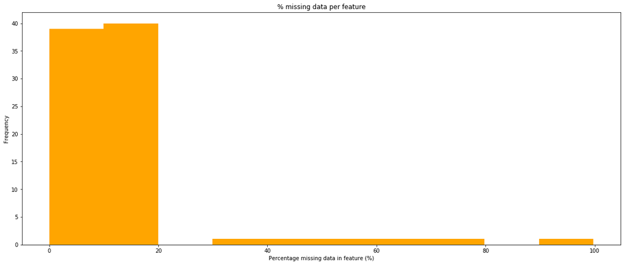

```python
# Create histogram with the frequency of columns and the percentage of missing data in them
plt.figure(figsize=(20,8))
plt.xlabel('Percentage missing data in feature (%)')
s4.plot.hist(title='% missing data per feature', color='orange')
```

**The histogram above illustrates the frequency of features and the percentage of missing data in them. The majority of the features have 0 to 20% missing data in them, and a few (6 features) have a higher percentage of missing data. These appear to be outliers.**

```python
s4.describe()
```

```
count    85.000000
mean     11.054139
std      16.449815
min       0.000000
25%       0.000000
50%      10.451729
75%      13.073637
max      99.757636
Name: percent_nan_column, dtype: float64
```

**The mean perecentage of missing data in a feature is 11%, and 75% of all features have 13% missing data or less.**

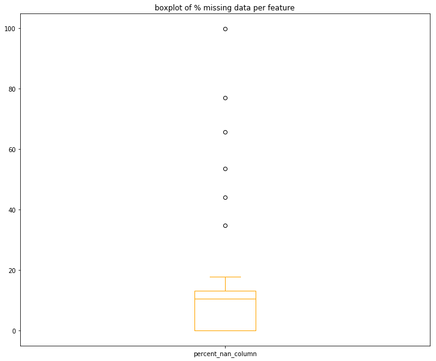

```python
# Create boxplot with the frequency of columns and the percentage of missing data in them
plt.figure(figsize=(12,10))
s4.plot.box(title='boxplot of % missing data per feature', color='orange')
```

**This boxplot of the percentage of missing data in each feature shows that there are 6 features that are outliers in the dataset, which have more than 20% missing data.**

```python
# Create array with columns with more than 20% missing data
s4[s4 > 20]
```

```
TITEL_KZ        99.757636
AGER_TYP        76.955435
KK_KUNDENTYP    65.596749
KBA05_BAUMAX    53.468668
GEBURTSJAHR     44.020282
ALTER_HH        34.813699
Name: percent_nan_column, dtype: float64
```

**The outliers in the data are listed above, the feature name is shown to the left and the percentage missing data in that feature is shown to the right.**

```python
# Create list of features with more than 20% missing data
highmissing_index = s4[s4 > 20].index.tolist()

# Print feat_info dataframe of features with more than 20% missing data
feat_info[feat_info.isin(highmissing_index).attribute == True]
```

|  | attribute | information_level | type | missing_or_unknown |
| --- | --- | --- | --- | --- |
| 0 | AGER_TYP | person | categorical | [-1,0] |
| 11 | GEBURTSJAHR | person | numeric | [0] |
| 40 | TITEL_KZ | person | categorical | [-1,0] |
| 43 | ALTER_HH | household | interval | [0] |
| 47 | KK_KUNDENTYP | household | categorical | [-1] |
| 64 | KBA05_BAUMAX | microcell_rr3 | mixed | [-1,0] |

**The table shows the feat_info dataframe with information on the features with more than 20% missing data in them. They all belong to mixed information level categories, such as person and household data.**

```python
# Remove the outlier columns from the dataset. (You'll perform other data
# engineering tasks such as re-encoding and imputation later.)

# Drop outlier columns from azdias dataframe
az_clean = az_clean.drop(columns=['TITEL_KZ',
                                  'AGER_TYP',
                                  'KK_KUNDENTYP',
                                  'KBA05_BAUMAX',
                                  'GEBURTSJAHR',
                                  'ALTER_HH'])

# Print number of rows and columns after removing outlier columns from dataframe
print('Number of rows (persons) after removing outlier columns: {}'.format(az_clean.shape[0]))
print('Number of columns (features) after removing outlier columns: {}'.format(az_clean.shape[1]))
```

```
Number of rows (persons) after removing outlier columns: 891221
Number of columns (features) after removing outlier columns: 79
```

```python
# Drop outlier columns from feat_info dataframe
fi_clean = feat_info.drop(feat_info[(feat_info['attribute'] == 'TITEL_KZ') |
                                    (feat_info['attribute'] == 'AGER_TYP') |
                                    (feat_info['attribute'] == 'KK_KUNDENTYP') |
                                    (feat_info['attribute'] == 'KBA05_BAUMAX') |
                                    (feat_info['attribute'] == 'GEBURTSJAHR') |
                                    (feat_info['attribute'] == 'ALTER_HH')].index)

print('Number of rows (features) after removing outlier columns: {}'.format(fi_clean.shape[0]))
print('Number of columns after removing outlier columns: {}'.format(fi_clean.shape[1]))
```

```
Number of rows (features) after removing outlier columns: 79
Number of columns after removing outlier columns: 4
```

#### Discussion 1.1.2: Assess Missing Data in Each Column

**There are 24 features in the dataset with no missing data at all and these belong to the person information level category. The mean percentage of missing data in a feature is 11%, and 75% of the features have 13% missing data or less.**

**Many of the features have the same number of missing data points. For example these features: PLZ8_ANTG1, PLZ8_ANTG2, PLZ8_ANTG3, PLZ8_ANTG4, PLZ8_BAUMAX, PLZ8_HHZ, and PLZ8_GBZ. They all belong to the same information level category, macrocell_plz8, which might mean they come from the same source or are based on the same root variable and that might be why they have exactly the same amount of missing data.**

**There are 6 outlier features that have more than 20% missing data in them: TITEL_KZ, AGER_TYP, KK_KUNDENTYP, KBA05_BAUMAX, GEBURTSJAHR and ALTER_HH. These have been removed from the dataframe.**

#### Step 1.1.3: Assess Missing Data in Each Row

Now, you'll perform a similar assessment for the rows of the dataset. How much data is missing in each row? As with the columns, you should see some groups of points that have a very different numbers of missing values. Divide the data into two subsets: one for data points that are above some threshold for missing values, and a second subset for points below that threshold.

In order to know what to do with the outlier rows, we should see if the distribution of data values on columns that are not missing data (or are missing very little data) are similar or different between the two groups. Select at least five of these columns and compare the distribution of values.

- You can use seaborn's [`countplot()`](https://seaborn.pydata.org/generated/seaborn.countplot.html) function to create a bar chart of code frequencies and matplotlib's [`subplot()`](https://matplotlib.org/api/_as_gen/matplotlib.pyplot.subplot.html) function to put bar charts for the two subplots side by side.
- To reduce repeated code, you might want to write a function that can perform this comparison, taking as one of its arguments a column to be compared.

Depending on what you observe in your comparison, this will have implications on how you approach your conclusions later in the analysis. If the distributions of non-missing features look similar between the data with many missing values and the data with few or no missing values, then we could argue that simply dropping those points from the analysis won't present a major issue. On the other hand, if the data with many missing values looks very different from the data with few or no missing values, then we should make a note on those data as special. We'll revisit these data later on. **Either way, you should continue your analysis for now using just the subset of the data with few or no missing values.**

```python
# How much data is missing in each row of the dataset?

# Create array with number of missing data points per row
s5 = pd.Series(az_clean.isnull().sum(axis=1), name='missing_per_row')
s5.describe()
```

```
count    891221.000000
mean          5.649894
std          13.234687
min           0.000000
25%           0.000000
50%           0.000000
75%           3.000000
max          49.000000
Name: missing_per_row, dtype: float64
```

**The mean for number of missing data points per person/sample (row) is 5.6 missing data points. 75% of the samples have 3 missing data points or less.**

```python
# Print row counts per number of missing data points, sorted by index
s5.value_counts().sort_index()
```

```
0     623209
1      15738
2      27926
3      17629
4      12607
5      22515
6      13771
7      13714
8      24592
9       3042
10      5410
11      1127
12       766
13      3255
14      2243
```

[output cut: 35 more lines]

```python
# Create array with percentage of missing data points per row
s6 = pd.Series((s5 / az_clean.shape[1]) * 100, name='percent_nan_row')
s6 = s6.sort_values(ascending=False)

# Print row percentage per number of missing data points, sorted by index
s6.round(decimals=1).value_counts().sort_index()
```

```
0.0     623209
1.3      15738
2.5      27926
3.8      17629
5.1      12607
6.3      22515
7.6      13771
8.9      13714
10.1     24592
11.4      3042
12.7      5410
13.9      1127
15.2       766
16.5      3255
17.7      2243
19.0      4743
20.3      2505
21.5       677
22.8       428
24.1      1180
25.3       349
26.6       150
27.8       129
29.1       132
30.4        69
31.6        55
32.9        59
34.2        24
35.4         5
36.7        12
38.0         6
39.2         3
40.5       206
41.8      2985
43.0     10816
44.3      3911
45.6        84
46.8       538
48.1       421
49.4        77
50.6       137
51.9       356
53.2        21
54.4     27369
55.7       155
57.0       494
59.5     45578
60.8         1
62.0         2
Name: percent_nan_row, dtype: int64
```

**623 209 samples have no missing data at all. If we look at the distribution of missing data, something that stands out is that a big portion has 59,5% missing data - 45 578 samples.**

```python
# Calculate and print percentage of rows with no missing data of total rows
print('Percentage of samples with no missing data of total samples in dataframe: {:.1f}%'
      .format((s5[s5 == 0].count() / az_clean.shape[0]) * 100))
```

```
Percentage of samples with no missing data of total samples in dataframe: 69.9%
```

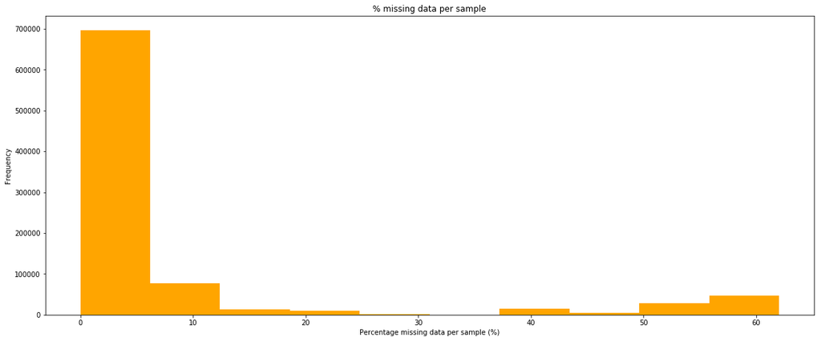

```python
# Create histogram with the frequency of rows and the percentage of missing data in them
plt.figure(figsize=(20,8))
plt.xlabel('Percentage missing data per sample (%)')
s6.plot.hist(title='% missing data per sample', color='orange')
```

**The histogram above illustrates the frequency of samples and the percentage of missing data in them. The majority of the samples have less than 10% missing data in them, and a few have more than 40% missing data.**

```python
# Write code to divide the data into two subsets based on the number of missing
# values in each row.

# Create column with number of missing data points per row
az_clean['percentage_nan_per_row'] = (az_clean.isnull().sum(axis=1) / az_clean.shape[1]) * 100

# Create two new dataframes, one with no missing data and one with missing data
az_lownan = az_clean[az_clean['percentage_nan_per_row'] <= 31]
az_highnan = az_clean[az_clean['percentage_nan_per_row'] > 31]

# Drop the added missing data per row column from dataframes
az_lownan = az_lownan.drop(columns='percentage_nan_per_row')
az_highnan = az_highnan.drop(columns='percentage_nan_per_row')

print('Number of samples in dataframe with no missing data: {}'.format(az_lownan.shape[0]))
print('Number of samples in dataframe with missing data: {}'.format(az_highnan.shape[0]))
```

```
Number of samples in dataframe with no missing data: 797906
Number of samples in dataframe with missing data: 93315
```

```python
# Calculate and print percentage of rows kept in az_lownan compared to original dataset
print('Percentage of samples in az_lownan compared to original dataset: {:.1f}%'
      .format((az_lownan.shape[0] / az_clean.shape[0]) * 100))
```

```
Percentage of samples in az_lownan compared to original dataset: 89.5%
```

**Looking at the graph of percentage missing data points per sample above, there seems to be a gap between 31% and 37% missing data per row, which visually divides the data into two groups. I have decided to subset the data based on this, with a cutoff at 31% for the subset with a low number of missing data. The az_lownan dataset includes samples with 0-31% missing data per row and the az_highnan includes samples with more than 31% missing data per row.**

```python
# Compare the distribution of values for at least five columns where there are
# no or few missing values, between the two subsets.

# Columns with no missing data
s4[s4 == 0]
```

```
FINANZTYP                0.0
GREEN_AVANTGARDE         0.0
FINANZ_HAUSBAUER         0.0
FINANZ_UNAUFFAELLIGER    0.0
FINANZ_ANLEGER           0.0
FINANZ_SPARER            0.0
FINANZ_MINIMALIST        0.0
ANREDE_KZ                0.0
FINANZ_VORSORGER         0.0
SEMIO_FAM                0.0
SEMIO_SOZ                0.0
SEMIO_REL                0.0
SEMIO_MAT                0.0
SEMIO_VERT               0.0
SEMIO_LUST               0.0
SEMIO_ERL                0.0
SEMIO_KULT               0.0
SEMIO_RAT                0.0
SEMIO_KRIT               0.0
SEMIO_DOM                0.0
SEMIO_KAEM               0.0
SEMIO_PFLICHT            0.0
SEMIO_TRADV              0.0
ZABEOTYP                 0.0
Name: percent_nan_column, dtype: float64
```

**Above we can see all columns with no missing data in them at all.**

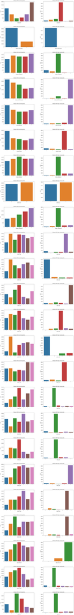

```python
# Create list of columns with no missing data
col_compare = s4[s4==0].index.tolist()

# Create countplots per dataset and column and a for loop to iterate over columns with no missing data
fig, ax = plt.subplots(nrows=len(col_compare), ncols=2, figsize=(20,180))
fig.subplots_adjust(hspace=.3, wspace=.3)

for i in range(len(col_compare)):
    sns.countplot(az_lownan[col_compare[i]], ax=ax[i][0]).set_title('Dataset with low missing data')
    sns.countplot(az_highnan[col_compare[i]], ax=ax[i][1]).set_title('Dataset with high missing data')
```

#### Discussion 1.1.3: Assess Missing Data in Each Row

**I have decided to subset the data with a cutoff at 31% of missing data per row for the subset with a low number of missing data, az_lownan. This means that we have excluded just of 10% of the original data, which is not that much I would say. However, looking at the comparing graphs of features with no missing data in them between the subsets with low missing data and high missing data respectively, we can see that the data distribution in these features differ quite a lot between the subsets. All feature distributions differ between the datasets except for the gender feature (*ANREDE_KZ*), which seem to have a similar distribution across the datasets. In general, it looks like the dataset with low missing data has more evenly distributed data across the values in a feature, meanwhile the dataset with high missing data seems to be more centered around one value in a feature.**

### Step 1.2: Select and Re-Encode Features

Checking for missing data isn't the only way in which you can prepare a dataset for analysis. Since the unsupervised learning techniques to be used will only work on data that is encoded numerically, you need to make a few encoding changes or additional assumptions to be able to make progress. In addition, while almost all of the values in the dataset are encoded using numbers, not all of them represent numeric values. Check the third column of the feature summary (`feat_info`) for a summary of types of measurement.

- For numeric and interval data, these features can be kept without changes.
- Most of the variables in the dataset are ordinal in nature. While ordinal values may technically be non-linear in spacing, make the simplifying assumption that the ordinal variables can be treated as being interval in nature (that is, kept without any changes).
- Special handling may be necessary for the remaining two variable types: categorical, and 'mixed'.

In the first two parts of this sub-step, you will perform an investigation of the categorical and mixed-type features and make a decision on each of them, whether you will keep, drop, or re-encode each. Then, in the last part, you will create a new data frame with only the selected and engineered columns.

Data wrangling is often the trickiest part of the data analysis process, and there's a lot of it to be done here. But stick with it: once you're done with this step, you'll be ready to get to the machine learning parts of the project!

```python
# How many features are there of each data type?

# Count and print values in column 'type'
fi_clean.type.value_counts()
```

```
ordinal        49
categorical    18
mixed           6
numeric         6
Name: type, dtype: int64
```

**Most of the features have data of ordinal or categorical type. 18 categorical and 6 mixed features need special handling.**

#### Step 1.2.1: Re-Encode Categorical Features

For categorical data, you would ordinarily need to encode the levels as dummy variables. Depending on the number of categories, perform one of the following:

- For binary (two-level) categoricals that take numeric values, you can keep them without needing to do anything.
- There is one binary variable that takes on non-numeric values. For this one, you need to re-encode the values as numbers or create a dummy variable.
- For multi-level categoricals (three or more values), you can choose to encode the values using multiple dummy variables (e.g. via [OneHotEncoder](http://scikit-learn.org/stable/modules/generated/sklearn.preprocessing.OneHotEncoder.html)), or (to keep things straightforward) just drop them from the analysis. As always, document your choices in the Discussion section.

```python
fi_clean[fi_clean['type'] == 'categorical']
```

|  | attribute | information_level | type | missing_or_unknown |
| --- | --- | --- | --- | --- |
| 2 | ANREDE_KZ | person | categorical | [-1,0] |
| 3 | CJT_GESAMTTYP | person | categorical | [0] |
| 10 | FINANZTYP | person | categorical | [-1] |
| 12 | GFK_URLAUBERTYP | person | categorical | [] |
| 13 | GREEN_AVANTGARDE | person | categorical | [] |
| 17 | LP_FAMILIE_FEIN | person | categorical | [0] |
| 18 | LP_FAMILIE_GROB | person | categorical | [0] |
| 19 | LP_STATUS_FEIN | person | categorical | [0] |
| 20 | LP_STATUS_GROB | person | categorical | [0] |
| 21 | NATIONALITAET_KZ | person | categorical | [-1,0] |
| 38 | SHOPPER_TYP | person | categorical | [-1] |
| 39 | SOHO_KZ | person | categorical | [-1] |
| 41 | VERS_TYP | person | categorical | [-1] |
| 42 | ZABEOTYP | person | categorical | [-1,9] |
| 52 | GEBAEUDETYP | building | categorical | [-1,0] |
| 55 | OST_WEST_KZ | building | categorical | [-1] |
| 57 | CAMEO_DEUG_2015 | microcell_rr4 | categorical | [-1,X] |
| 58 | CAMEO_DEU_2015 | microcell_rr4 | categorical | [XX] |

**All categorical features are listed above.**

```python
# Assess categorical variables: which are binary, which are multi-level, and
# which one needs to be re-encoded?

# Create list of categorical columns
categorical_features = fi_clean[fi_clean['type'] == 'categorical'].attribute.tolist()

# Create binary and multi level lists and a for loop to iterate over categorical columns and append to correct list
binary_col = []
multilevel_col = []

for i in categorical_features:
    if az_lownan[i].nunique() == 2:
        binary_col.append(i)
    else:
        multilevel_col.append(i)

# Print number of binary and multilevel categorical columns
print('Number of binary categorical features: {}'.format(len(binary_col)))
print('Number of multi level categorical features: {}'.format(len(multilevel_col)))
```

```
Number of binary categorical features: 5
Number of multi level categorical features: 13
```

```python
# Print binary categorical columns and their data type
for i in binary_col:
    print('Data type for {}: {}'.format(i, az_lownan[i].dtypes))
```

```
Data type for ANREDE_KZ: int64
Data type for GREEN_AVANTGARDE: int64
Data type for SOHO_KZ: float64
Data type for VERS_TYP: float64
Data type for OST_WEST_KZ: object
```

```python
# Print binary categorical columns and their unique value codes
for i in binary_col:
    print('Unique value codes in {}: {}'.format(i, az_lownan[i].unique()))
```

```
Unique value codes in ANREDE_KZ: [2 1]
Unique value codes in GREEN_AVANTGARDE: [0 1]
Unique value codes in SOHO_KZ: [ 1.  0.]
Unique value codes in VERS_TYP: [  2.   1.  nan]
Unique value codes in OST_WEST_KZ: ['W' 'O']
```

**The feature *OST_WEST_KZ* has non-numeric values 'W' and 'O' and must be recoded to numerical values.**

```python
# Re-encode categorical variable(s) to be kept in the analysis.

# Recode non-numeric values in OST_WEST_KZ to numerical values
az_lownan = az_lownan.replace({'OST_WEST_KZ': {'W': 0, 'O': 1}})

# Print values and counts for OST_WEST_KZ
az_lownan.OST_WEST_KZ.value_counts()
```

```
0    629388
1    168518
Name: OST_WEST_KZ, dtype: int64
```

**The feature *OST_WEST_KZ* has been recoded to binary numerical values 0 and 1.**

```python
# Print multi level categorical columns and their data type
for i in multilevel_col:
    print('Data type for {}: {}'.format(i, az_lownan[i].dtypes))
```

```
Data type for CJT_GESAMTTYP: float64
Data type for FINANZTYP: int64
Data type for GFK_URLAUBERTYP: float64
Data type for LP_FAMILIE_FEIN: float64
Data type for LP_FAMILIE_GROB: float64
Data type for LP_STATUS_FEIN: float64
Data type for LP_STATUS_GROB: float64
Data type for NATIONALITAET_KZ: float64
Data type for SHOPPER_TYP: float64
Data type for ZABEOTYP: int64
Data type for GEBAEUDETYP: float64
Data type for CAMEO_DEUG_2015: object
Data type for CAMEO_DEU_2015: object
```

```python
# Print multi level categorical columns and their unique value codes
for i in multilevel_col:
    print('Unique value codes in {}: {}'.format(i, az_lownan[i].unique()))
```

```
Unique value codes in CJT_GESAMTTYP: [  5.   3.   2.   4.   1.   6.  nan]
Unique value codes in FINANZTYP: [1 6 5 2 4 3]
Unique value codes in GFK_URLAUBERTYP: [ 10.   1.   5.  12.   9.   3.   8.  11.   4.   2.   7.   6.  nan]
Unique value codes in LP_FAMILIE_FEIN: [  5.   1.  nan  10.   2.   7.  11.   8.   4.   6.   9.   3.]
Unique value codes in LP_FAMILIE_GROB: [  3.   1.  nan   5.   2.   4.]
Unique value codes in LP_STATUS_FEIN: [  2.   3.   9.   4.   1.  10.   5.   8.   6.   7.  nan]
Unique value codes in LP_STATUS_GROB: [  1.   2.   4.   5.   3.  nan]
Unique value codes in NATIONALITAET_KZ: [  1.   3.   2.  nan]
Unique value codes in SHOPPER_TYP: [  3.   2.   1.   0.  nan]
Unique value codes in ZABEOTYP: [5 3 4 1 6 2]
Unique value codes in GEBAEUDETYP: [ 8.  1.  3.  2.  6.  4.  5.]
Unique value codes in CAMEO_DEUG_2015: ['8' '4' '2' '6' '1' '9' '5' '7' nan '3']
Unique value codes in CAMEO_DEU_2015: ['8A' '4C' '2A' '6B' '8C' '4A' '2D' '1A' '1E' '9D' '5C' '8B' '7A' '5D' '9E'
 nan '9B' '1B' '3D' '4E' '4B' '3C' '5A' '7B' '9A' '6D' '6E' '2C' '7C' '9C'
 '7D' '5E' '1D' '8D' '6C' '6A' '5B' '4D' '3A' '2B' '7E' '3B' '6F' '5F' '1C']
```

```python
# One-hot encode multi level categorical columns
az_lownan = pd.get_dummies(az_lownan, columns=multilevel_col)

# Print dataframe info
az_lownan.info()
```

```
<class 'pandas.core.frame.DataFrame'>
Int64Index: 797906 entries, 1 to 891220
Columns: 194 entries, ALTERSKATEGORIE_GROB to CAMEO_DEU_2015_9E
dtypes: float64(42), int64(23), object(1), uint8(128)
memory usage: 505.3+ MB
```

```python
# Print columns in dataframe after one-hot encoding
for i in az_lownan.columns:
    print(i)
```

```
ALTERSKATEGORIE_GROB
ANREDE_KZ
FINANZ_MINIMALIST
FINANZ_SPARER
FINANZ_VORSORGER
FINANZ_ANLEGER
FINANZ_UNAUFFAELLIGER
FINANZ_HAUSBAUER
GREEN_AVANTGARDE
HEALTH_TYP
LP_LEBENSPHASE_FEIN
LP_LEBENSPHASE_GROB
PRAEGENDE_JUGENDJAHRE
RETOURTYP_BK_S
SEMIO_SOZ
SEMIO_FAM
SEMIO_REL
SEMIO_MAT
SEMIO_VERT
SEMIO_LUST
SEMIO_ERL
SEMIO_KULT
SEMIO_RAT
SEMIO_KRIT
SEMIO_DOM
SEMIO_KAEM
SEMIO_PFLICHT
SEMIO_TRADV
SOHO_KZ
VERS_TYP
ANZ_PERSONEN
ANZ_TITEL
HH_EINKOMMEN_SCORE
W_KEIT_KIND_HH
WOHNDAUER_2008
ANZ_HAUSHALTE_AKTIV
ANZ_HH_TITEL
KONSUMNAEHE
MIN_GEBAEUDEJAHR
OST_WEST_KZ
```

[output cut: 139 more lines]

```
CAMEO_DEU_2015_6F
CAMEO_DEU_2015_7A
CAMEO_DEU_2015_7B
CAMEO_DEU_2015_7C
CAMEO_DEU_2015_7D
CAMEO_DEU_2015_7E
CAMEO_DEU_2015_8A
CAMEO_DEU_2015_8B
CAMEO_DEU_2015_8C
CAMEO_DEU_2015_8D
CAMEO_DEU_2015_9A
CAMEO_DEU_2015_9B
CAMEO_DEU_2015_9C
CAMEO_DEU_2015_9D
CAMEO_DEU_2015_9E
```

**The dataframe info and columns are listed above after one-hot encoding all multi level categorical features.**

#### Discussion 1.2.1: Re-Encode Categorical Features

**There are 18 categorical features in the dataset, 5 of those are binary and 13 are multi level features. One of the binary features, *OST_WEST_KZ*, was non-numeric and had to be recoded to binary numeric codes 0 and 1. All multi level categorical features are kept in the dataset and have been one-hot encoded to be useful later on in the model prediction.**

#### Step 1.2.2: Engineer Mixed-Type Features

There are a handful of features that are marked as "mixed" in the feature summary that require special treatment in order to be included in the analysis. There are two in particular that deserve attention; the handling of the rest are up to your own choices:

- "PRAEGENDE_JUGENDJAHRE" combines information on three dimensions: generation by decade, movement (mainstream vs. avantgarde), and nation (east vs. west). While there aren't enough levels to disentangle east from west, you should create two new variables to capture the other two dimensions: an interval-type variable for decade, and a binary variable for movement.
- "CAMEO_INTL_2015" combines information on two axes: wealth and life stage. Break up the two-digit codes by their 'tens'-place and 'ones'-place digits into two new ordinal variables (which, for the purposes of this project, is equivalent to just treating them as their raw numeric values).
- If you decide to keep or engineer new features around the other mixed-type features, make sure you note your steps in the Discussion section.

Be sure to check `Data_Dictionary.md` for the details needed to finish these tasks.

```python
fi_clean[fi_clean['type'] == 'mixed']
```

|  | attribute | information_level | type | missing_or_unknown |
| --- | --- | --- | --- | --- |
| 15 | LP_LEBENSPHASE_FEIN | person | mixed | [0] |
| 16 | LP_LEBENSPHASE_GROB | person | mixed | [0] |
| 22 | PRAEGENDE_JUGENDJAHRE | person | mixed | [-1,0] |
| 56 | WOHNLAGE | building | mixed | [-1] |
| 59 | CAMEO_INTL_2015 | microcell_rr4 | mixed | [-1,XX] |
| 79 | PLZ8_BAUMAX | macrocell_plz8 | mixed | [-1,0] |

**All mixed categorical features are listed above.**

```python
# Investigate "PRAEGENDE_JUGENDJAHRE" and engineer two new variables.
az_lownan.PRAEGENDE_JUGENDJAHRE.value_counts().sort_index()
```

```
1.0      20678
2.0       7479
3.0      53840
4.0      20451
5.0      84682
6.0      25652
7.0       4009
8.0     141598
9.0      33569
10.0     85793
11.0     35746
12.0     24446
13.0      5762
14.0    182964
15.0     42540
Name: PRAEGENDE_JUGENDJAHRE, dtype: int64
```

```python
# Create columns DECADE and MOVEMENT, copy PRAEGENDE_JUGENDJAHRE for both
az_lownan['DECADE'] = az_lownan['PRAEGENDE_JUGENDJAHRE']
az_lownan['MOVEMENT'] = az_lownan['PRAEGENDE_JUGENDJAHRE']

# Create recoding dictionaries for new columns
decade_dict = {1:1, 2:1, 3:2, 4:2, 5:3, 6:3, 7:3, 8:4, 9:4, 10:5, 11:5, 12:5, 13:5, 14:6, 15:6}
movement_dict = {1:1, 2:0, 3:1, 4:0, 5:1, 6:0, 7:0, 8:1, 9:0, 10:1, 11:0, 12:1, 13:0, 14:1, 15:0}

# Replace columns with recoded data
az_lownan['DECADE'].replace(decade_dict, inplace=True)
az_lownan['MOVEMENT'].replace(movement_dict, inplace=True)

# Print value counts for recoded columns
print(az_lownan.DECADE.value_counts())
print(az_lownan.MOVEMENT.value_counts())
```

```
6.0    225504
4.0    175167
5.0    151747
3.0    114343
2.0     74291
1.0     28157
Name: DECADE, dtype: int64
1.0    594001
0.0    175208
Name: MOVEMENT, dtype: int64
```

```python
# Investigate "CAMEO_INTL_2015" and engineer two new variables.
az_lownan.CAMEO_INTL_2015.value_counts().sort_index()
```

```
12     13245
13     26332
14     62880
15     16974
22     33149
23     26732
24     91147
25     39624
31     19012
32     10354
33      9935
34     18524
35     10356
41     92336
43     56671
44     14820
45     26132
51    133691
52     20542
54     45390
55     23954
Name: CAMEO_INTL_2015, dtype: int64
```

```python
# Create columns WEALTH and LIFE_STAGE, copy CAMEO_INTL_2015 for both
az_lownan['WEALTH'] = az_lownan['CAMEO_INTL_2015']
az_lownan['LIFE_STAGE'] = az_lownan['CAMEO_INTL_2015']

# Create recoding dictionaries for new columns
wealth_dict = {'11':1, '12':1, '13':1, '14':1, '15':1, '21':2, '22':2, '23':2, '24':2, '25':2,
               '31':3, '32':3, '33':3, '34':3, '35':3, '41':4, '42':4, '43':4, '44':4, '45':4,
               '51':5, '52':5, '53':5, '54':5, '55':5}

lifestage_dict = {'11':1, '12':2, '13':3, '14':4, '15':5, '21':1, '22':2, '23':3, '24':4, '25':5,
                   '31':1, '32':2, '33':3, '34':4, '35':5, '41':1, '42':2, '43':3, '44':4, '45':5,
                   '51':1, '52':2, '53':3, '54':4, '55':5}

# Replace columns with recoded data
az_lownan['WEALTH'].replace(wealth_dict, inplace=True)
az_lownan['LIFE_STAGE'].replace(lifestage_dict, inplace=True)

# Print value counts for recoded columns
print(az_lownan.WEALTH.value_counts())
print(az_lownan.LIFE_STAGE.value_counts())
```

```
5.0    223577
2.0    190652
4.0    189959
1.0    119431
3.0     68181
Name: WEALTH, dtype: int64
1.0    245039
4.0    232761
3.0    119670
5.0    117040
2.0     77290
Name: LIFE_STAGE, dtype: int64
```

```python
# Drop original columns from dataframe
az_lownan = az_lownan.drop(columns=['PRAEGENDE_JUGENDJAHRE', 'CAMEO_INTL_2015'])

# Drop original columns from feat_info
fi_clean = fi_clean.drop(fi_clean[(fi_clean['attribute'] == 'PRAEGENDE_JUGENDJAHRE') |
                                    (fi_clean['attribute'] == 'CAMEO_INTL_2015')].index)
```

```python
# Create list of mixed features
mixed_col = fi_clean[fi_clean['type'] == 'mixed'].attribute.tolist()

# One-hot encode remaining mixed columns
az_lownan = pd.get_dummies(az_lownan, columns=mixed_col)

# Print dataframe info
az_lownan.info()
```

```
<class 'pandas.core.frame.DataFrame'>
Int64Index: 797906 entries, 1 to 891220
Columns: 257 entries, ALTERSKATEGORIE_GROB to PLZ8_BAUMAX_5.0
dtypes: float64(41), int64(23), uint8(193)
memory usage: 542.6 MB
```

#### Discussion 1.2.2: Engineer Mixed-Type Features

**The mixed columns *PRAEGENDE_JUGENDJAHRE* and *CAMEO_INTL_2015* have been recoded and split into two new variables each. *PRAEGENDE_JUGENDJAHRE* is now numeric columns *DECADE* and *MOVEMENT*, and *CAMEO_INTL_2015* is numeric columns *WEALTH* and *LIFE_STAGE*. Both original columns have been dropped from the dataframe. The remaining mixed columns are kept in the dataset and have been one-hot encoded.**

#### Step 1.2.3: Complete Feature Selection

In order to finish this step up, you need to make sure that your data frame now only has the columns that you want to keep. To summarize, the dataframe should consist of the following:

- All numeric, interval, and ordinal type columns from the original dataset.
- Binary categorical features (all numerically-encoded).
- Engineered features from other multi-level categorical features and mixed features.

Make sure that for any new columns that you have engineered, that you've excluded the original columns from the final dataset. Otherwise, their values will interfere with the analysis later on the project. For example, you should not keep "PRAEGENDE_JUGENDJAHRE", since its values won't be useful for the algorithm: only the values derived from it in the engineered features you created should be retained. As a reminder, your data should only be from **the subset with few or no missing values**.

```python
# If there are other re-engineering tasks you need to perform, make sure you
# take care of them here. (Dealing with missing data will come in step 2.1.)
```

```python
# Do whatever you need to in order to ensure that the dataframe only contains
# the columns that should be passed to the algorithm functions.

# Print data types, show all columns
with pd.option_context("display.max_rows", 300):
    print(az_lownan.dtypes)
```

```
ALTERSKATEGORIE_GROB        float64
ANREDE_KZ                     int64
FINANZ_MINIMALIST             int64
FINANZ_SPARER                 int64
FINANZ_VORSORGER              int64
FINANZ_ANLEGER                int64
FINANZ_UNAUFFAELLIGER         int64
FINANZ_HAUSBAUER              int64
GREEN_AVANTGARDE              int64
HEALTH_TYP                  float64
RETOURTYP_BK_S              float64
SEMIO_SOZ                     int64
SEMIO_FAM                     int64
SEMIO_REL                     int64
SEMIO_MAT                     int64
SEMIO_VERT                    int64
SEMIO_LUST                    int64
SEMIO_ERL                     int64
SEMIO_KULT                    int64
SEMIO_RAT                     int64
SEMIO_KRIT                    int64
SEMIO_DOM                     int64
SEMIO_KAEM                    int64
SEMIO_PFLICHT                 int64
SEMIO_TRADV                   int64
SOHO_KZ                     float64
VERS_TYP                    float64
ANZ_PERSONEN                float64
ANZ_TITEL                   float64
HH_EINKOMMEN_SCORE          float64
W_KEIT_KIND_HH              float64
WOHNDAUER_2008              float64
ANZ_HAUSHALTE_AKTIV         float64
ANZ_HH_TITEL                float64
KONSUMNAEHE                 float64
MIN_GEBAEUDEJAHR            float64
OST_WEST_KZ                   int64
KBA05_ANTG1                 float64
KBA05_ANTG2                 float64
KBA05_ANTG3                 float64
```

[output cut: 203 more lines]

```
LP_LEBENSPHASE_GROB_12.0      uint8
WOHNLAGE_0.0                  uint8
WOHNLAGE_1.0                  uint8
WOHNLAGE_2.0                  uint8
WOHNLAGE_3.0                  uint8
WOHNLAGE_4.0                  uint8
WOHNLAGE_5.0                  uint8
WOHNLAGE_7.0                  uint8
WOHNLAGE_8.0                  uint8
PLZ8_BAUMAX_1.0               uint8
PLZ8_BAUMAX_2.0               uint8
PLZ8_BAUMAX_3.0               uint8
PLZ8_BAUMAX_4.0               uint8
PLZ8_BAUMAX_5.0               uint8
dtype: object
```

**It appears that all columns have been removed that should, and that the rest have been recoded properly.**

### Step 1.3: Create a Cleaning Function

Even though you've finished cleaning up the general population demographics data, it's important to look ahead to the future and realize that you'll need to perform the same cleaning steps on the customer demographics data. In this substep, complete the function below to execute the main feature selection, encoding, and re-engineering steps you performed above. Then, when it comes to looking at the customer data in Step 3, you can just run this function on that DataFrame to get the trimmed dataset in a single step.

```python
def clean_data(df1, df2):
    """
    Perform feature trimming, recoding, and engineering for demographics
    data

    INPUT: Demographics dataframe and feature summary
    OUTPUT: Trimmed and cleaned demographics dataframe split in two: dataframe with low number of missing data,
            dataframe with high number of missing data, and cleaned feature summary dataframe
    """

    # Put in code here to execute all main cleaning steps:
    # convert missing value codes into NaNs, ...

    # Create copy of dataframe
    df1_clean = df1.copy()

    # Replace codes for missing data from df2 with NaN values
    for i in range(len(df2)):
        missing_or_unknown = df2.iloc[i]['missing_or_unknown'].strip('[, ]').split(',')
        missing_or_unknown = [int(value) if (value!='X' and value!='XX' and value!='') else
                              value for value in missing_or_unknown]
        if missing_or_unknown != ['']:
            df1_clean = df1_clean.replace({df2.iloc[i]['attribute']: missing_or_unknown}, np.nan)

    # remove selected columns and rows, ...

    # Drop outlier columns from df1
    df1_clean = df1_clean.drop(columns=['TITEL_KZ',
                                        'AGER_TYP',
                                        'KK_KUNDENTYP',
                                        'KBA05_BAUMAX',
                                        'GEBURTSJAHR',
                                        'ALTER_HH'])

    # Drop outlier columns from df2
    df2_clean = df2.drop(df2[(df2['attribute'] == 'TITEL_KZ') |
                             (df2['attribute'] == 'AGER_TYP') |
                             (df2['attribute'] == 'KK_KUNDENTYP') |
                             (df2['attribute'] == 'KBA05_BAUMAX') |
                             (df2['attribute'] == 'GEBURTSJAHR') |
                             (df2['attribute'] == 'ALTER_HH')].index)

    # Create column with number of missing data points per row
    df1_clean['percentage_nan_per_row'] = (df1_clean.isnull().sum(axis=1) / df1_clean.shape[1]) * 100

    # Create two new dataframes, one with no missing data and one with missing data
    df1_lownan = df1_clean[df1_clean['percentage_nan_per_row'] <= 31]
    df1_highnan = df1_clean[df1_clean['percentage_nan_per_row'] > 31]

    # Drop the added missing data per row column from dataframes
    df1_lownan = df1_lownan.drop(columns='percentage_nan_per_row')
    df1_highnan = df1_highnan.drop(columns='percentage_nan_per_row')


    # Cleaning function for df1_lownan

    # Select, re-encode, and engineer column values.

    # Create list of categorical columns
    categorical_features = df2_clean[df2_clean['type'] == 'categorical'].attribute.tolist()

    # Create binary and multi level lists and a for loop to iterate over categorical columns
    # and append to correct list
    binary_col = []
    multilevel_col = []

    for i in categorical_features:
        if df1_lownan[i].nunique() == 2:
            binary_col.append(i)
        else:
            multilevel_col.append(i)

    # Recode non-numeric values in OST_WEST_KZ to numerical values
    df1_lownan = df1_lownan.replace({'OST_WEST_KZ': {'W': 0, 'O': 1}})

    # One-hot encode multi level categorical columns
    df1_lownan = pd.get_dummies(df1_lownan, columns=multilevel_col)

    # Create columns DECADE and MOVEMENT, copy PRAEGENDE_JUGENDJAHRE for both
    df1_lownan['DECADE'] = df1_lownan['PRAEGENDE_JUGENDJAHRE']
    df1_lownan['MOVEMENT'] = df1_lownan['PRAEGENDE_JUGENDJAHRE']

    # Create recoding dictionaries for new columns
    decade_dict = {1:1, 2:1, 3:2, 4:2, 5:3, 6:3, 7:3, 8:4, 9:4, 10:5, 11:5, 12:5, 13:5, 14:6, 15:6}
    movement_dict = {1:1, 2:0, 3:1, 4:0, 5:1, 6:0, 7:0, 8:1, 9:0, 10:1, 11:0, 12:1, 13:0, 14:1, 15:0}

    # Replace columns with recoded data
    df1_lownan['DECADE'].replace(decade_dict, inplace=True)
    df1_lownan['MOVEMENT'].replace(movement_dict, inplace=True)

    # Create columns WEALTH and LIFE_STAGE, copy CAMEO_INTL_2015 for both
    df1_lownan['WEALTH'] = df1_lownan['CAMEO_INTL_2015']
    df1_lownan['LIFE_STAGE'] = df1_lownan['CAMEO_INTL_2015']

    # Create recoding dictionaries for new columns
    wealth_dict = {'11':1, '12':1, '13':1, '14':1, '15':1, '21':2, '22':2, '23':2, '24':2, '25':2,
                   '31':3, '32':3, '33':3, '34':3, '35':3, '41':4, '42':4, '43':4, '44':4, '45':4,
                   '51':5, '52':5, '53':5, '54':5, '55':5}

    lifestage_dict = {'11':1, '12':2, '13':3, '14':4, '15':5, '21':1, '22':2, '23':3, '24':4, '25':5,
                      '31':1, '32':2, '33':3, '34':4, '35':5, '41':1, '42':2, '43':3, '44':4, '45':5,
                      '51':1, '52':2, '53':3, '54':4, '55':5}

    # Replace columns with recoded data
    df1_lownan['WEALTH'].replace(wealth_dict, inplace=True)
    df1_lownan['LIFE_STAGE'].replace(lifestage_dict, inplace=True)

    # Drop original columns from df1
    df1_lownan = df1_lownan.drop(columns=['PRAEGENDE_JUGENDJAHRE', 'CAMEO_INTL_2015'])

    # Drop original columns from df2
    df2_clean = df2_clean.drop(df2_clean[(df2_clean['attribute'] == 'PRAEGENDE_JUGENDJAHRE') |
                                         (df2_clean['attribute'] == 'CAMEO_INTL_2015')].index)

    # Create list of mixed features
    mixed_col = df2_clean[df2_clean['type'] == 'mixed'].attribute.tolist()

    # One-hot encode remaining mixed columns
    df1_lownan = pd.get_dummies(df1_lownan, columns=mixed_col)


    # Cleaning function for df1_highnan

    # Select, re-encode, and engineer column values.

    # Recode non-numeric values in OST_WEST_KZ to numerical values
    df1_highnan = df1_highnan.replace({'OST_WEST_KZ': {'W': 0, 'O': 1}})

    # One-hot encode multi level categorical columns
    df1_highnan = pd.get_dummies(df1_highnan, columns=multilevel_col)

    # Create columns DECADE and MOVEMENT, copy PRAEGENDE_JUGENDJAHRE for both
    df1_highnan['DECADE'] = df1_highnan['PRAEGENDE_JUGENDJAHRE']
    df1_highnan['MOVEMENT'] = df1_highnan['PRAEGENDE_JUGENDJAHRE']

    # Replace columns with recoded data
    df1_highnan['DECADE'].replace(decade_dict, inplace=True)
    df1_highnan['MOVEMENT'].replace(movement_dict, inplace=True)

    # Create columns WEALTH and LIFE_STAGE, copy CAMEO_INTL_2015 for both
    df1_highnan['WEALTH'] = df1_highnan['CAMEO_INTL_2015']
    df1_highnan['LIFE_STAGE'] = df1_highnan['CAMEO_INTL_2015']

    # Replace columns with recoded data
    df1_highnan['WEALTH'].replace(wealth_dict, inplace=True)
    df1_highnan['LIFE_STAGE'].replace(lifestage_dict, inplace=True)

    # Drop original columns from df1
    df1_highnan = df1_highnan.drop(columns=['PRAEGENDE_JUGENDJAHRE', 'CAMEO_INTL_2015'])

    # One-hot encode remaining mixed columns
    df1_highnan = pd.get_dummies(df1_highnan, columns=mixed_col)


    # Return the cleaned dataframe.
    return df1_lownan, df1_highnan, df1_clean, df2_clean
```

```python
# Run function on datasets and store created dataframes
az_lownan, az_highnan, az_clean, fi_clean = clean_data(azdias, feat_info)
```

```python
# Print created dataframes to check that they are correct
print(az_lownan.info())
print('')
print(az_highnan.info())
print('')
print(az_clean.info())
print('')
print(fi_clean.info())
```

```
<class 'pandas.core.frame.DataFrame'>
Int64Index: 797906 entries, 1 to 891220
Columns: 257 entries, ALTERSKATEGORIE_GROB to PLZ8_BAUMAX_5.0
dtypes: float64(41), int64(23), uint8(193)
memory usage: 542.6 MB
None

<class 'pandas.core.frame.DataFrame'>
Int64Index: 93315 entries, 0 to 891187
Columns: 225 entries, ALTERSKATEGORIE_GROB to WOHNLAGE_8.0
dtypes: float64(42), int64(22), uint8(161)
memory usage: 60.6 MB
None

<class 'pandas.core.frame.DataFrame'>
RangeIndex: 891221 entries, 0 to 891220
Data columns (total 80 columns):
ALTERSKATEGORIE_GROB      888340 non-null float64
ANREDE_KZ                 891221 non-null int64
CJT_GESAMTTYP             886367 non-null float64
FINANZ_MINIMALIST         891221 non-null int64
FINANZ_SPARER             891221 non-null int64
FINANZ_VORSORGER          891221 non-null int64
FINANZ_ANLEGER            891221 non-null int64
FINANZ_UNAUFFAELLIGER     891221 non-null int64
FINANZ_HAUSBAUER          891221 non-null int64
FINANZTYP                 891221 non-null int64
GFK_URLAUBERTYP           886367 non-null float64
GREEN_AVANTGARDE          891221 non-null int64
HEALTH_TYP                780025 non-null float64
LP_LEBENSPHASE_FEIN       793589 non-null float64
LP_LEBENSPHASE_GROB       796649 non-null float64
LP_FAMILIE_FEIN           813429 non-null float64
LP_FAMILIE_GROB           813429 non-null float64
LP_STATUS_FEIN            886367 non-null float64
LP_STATUS_GROB            886367 non-null float64
NATIONALITAET_KZ          782906 non-null float64
PRAEGENDE_JUGENDJAHRE     783057 non-null float64
RETOURTYP_BK_S            886367 non-null float64
SEMIO_SOZ                 891221 non-null int64
```

[output cut: 56 more lines]

```
percentage_nan_per_row    891221 non-null float64
dtypes: float64(52), int64(24), object(4)
memory usage: 544.0+ MB
None

<class 'pandas.core.frame.DataFrame'>
Int64Index: 77 entries, 1 to 84
Data columns (total 4 columns):
attribute             77 non-null object
information_level     77 non-null object
type                  77 non-null object
missing_or_unknown    77 non-null object
dtypes: object(4)
memory usage: 3.0+ KB
None
```

```python
# Compare columns between az_lownan and az_highnan
print(list(set(az_lownan.columns) - set(az_highnan)))
print('')
print(list(set(az_highnan.columns) - set(az_lownan)))
```

```
['CAMEO_DEU_2015_9A', 'PLZ8_BAUMAX_3.0', 'CAMEO_DEU_2015_1B', 'CAMEO_DEU_2015_8B', 'CAMEO_DEU_2015_1D', 'CAMEO_DEU_2015_9D', 'CAMEO_DEU_2015_5D', 'CAMEO_DEU_2015_5E', 'CAMEO_DEU_2015_1E', 'CAMEO_DEU_2015_7C', 'CAMEO_DEU_2015_7B', 'PLZ8_BAUMAX_5.0', 'CAMEO_DEU_2015_4D', 'CAMEO_DEU_2015_1A', 'CAMEO_DE…

[]
```

**After cleaning all dataframes, we can see that there are more columns in az_lownan compared to az_highnan. All of these columns have been added after one-hot encoding, and if that value wasn't present in the original dataframe column it will not be encoded as a new binary column. We might have to add these columns to the az_highnan dataframe later to keep the same structure of the datasets later on, but for now I will keep the dataframes as they are.**

## Step 2: Feature Transformation

### Step 2.1: Apply Feature Scaling

Before we apply dimensionality reduction techniques to the data, we need to perform feature scaling so that the principal component vectors are not influenced by the natural differences in scale for features. Starting from this part of the project, you'll want to keep an eye on the [API reference page for sklearn](http://scikit-learn.org/stable/modules/classes.html) to help you navigate to all of the classes and functions that you'll need. In this substep, you'll need to check the following:

- sklearn requires that data not have missing values in order for its estimators to work properly. So, before applying the scaler to your data, make sure that you've cleaned the DataFrame of the remaining missing values. This can be as simple as just removing all data points with missing data, or applying an [Imputer](http://scikit-learn.org/stable/modules/generated/sklearn.preprocessing.Imputer.html) to replace all missing values. You might also try a more complicated procedure where you temporarily remove missing values in order to compute the scaling parameters before re-introducing those missing values and applying imputation. Think about how much missing data you have and what possible effects each approach might have on your analysis, and justify your decision in the discussion section below.
- For the actual scaling function, a [StandardScaler](http://scikit-learn.org/stable/modules/generated/sklearn.preprocessing.StandardScaler.html) instance is suggested, scaling each feature to mean 0 and standard deviation 1.
- For these classes, you can make use of the `.fit_transform()` method to both fit a procedure to the data as well as apply the transformation to the data at the same time. Don't forget to keep the fit sklearn objects handy, since you'll be applying them to the customer demographics data towards the end of the project.

```python
# If you've not yet cleaned the dataset of all NaN values, then investigate and
# do that now.

# Check number of NaN values in dataframe
az_lownan.isnull().sum().sum()
```

```
760310
```

```python
# Initialize an imputer
imputer = Imputer(strategy='median')

# Apply imputer to dataframe to replace NaNs
az_lownan_imputed = pd.DataFrame(data=imputer.fit_transform(az_lownan), columns=az_lownan.columns)

# Print first 15 rows of the dataframe to see that transformation is implemented
az_lownan_imputed.head()
```

|  | ALTERSKATEGORIE_GROB | ANREDE_KZ | FINANZ_MINIMALIST | FINANZ_SPARER | FINANZ_VORSORGER | FINANZ_ANLEGER | FINANZ_UNAUFFAELLIGER | FINANZ_HAUSBAUER | GREEN_AVANTGARDE | HEALTH_TYP | ... | WOHNLAGE_3.0 | WOHNLAGE_4.0 | WOHNLAGE_5.0 | WOHNLAGE_7.0 | WOHNLAGE_8.0 | PLZ8_BAUMAX_1.0 | PLZ8_BAUMAX_2.0 | PLZ8_BAUMAX_3.0 | PLZ8_BAUMAX_4.0 | PLZ8_BAUMAX_5.0 |
| --- | --- | --- | --- | --- | --- | --- | --- | --- | --- | --- | --- | --- | --- | --- | --- | --- | --- | --- | --- | --- | --- |
| 0 | 1.0 | 2.0 | 1.0 | 5.0 | 2.0 | 5.0 | 4.0 | 5.0 | 0.0 | 3.0 | ... | 0.0 | 1.0 | 0.0 | 0.0 | 0.0 | 1.0 | 0.0 | 0.0 | 0.0 | 0.0 |
| 1 | 3.0 | 2.0 | 1.0 | 4.0 | 1.0 | 2.0 | 3.0 | 5.0 | 1.0 | 3.0 | ... | 0.0 | 0.0 | 0.0 | 0.0 | 0.0 | 1.0 | 0.0 | 0.0 | 0.0 | 0.0 |
| 2 | 4.0 | 2.0 | 4.0 | 2.0 | 5.0 | 2.0 | 1.0 | 2.0 | 0.0 | 2.0 | ... | 0.0 | 0.0 | 0.0 | 1.0 | 0.0 | 1.0 | 0.0 | 0.0 | 0.0 | 0.0 |
| 3 | 3.0 | 1.0 | 4.0 | 3.0 | 4.0 | 1.0 | 3.0 | 2.0 | 0.0 | 3.0 | ... | 1.0 | 0.0 | 0.0 | 0.0 | 0.0 | 0.0 | 1.0 | 0.0 | 0.0 | 0.0 |
| 4 | 1.0 | 2.0 | 3.0 | 1.0 | 5.0 | 2.0 | 2.0 | 5.0 | 0.0 | 3.0 | ... | 0.0 | 0.0 | 0.0 | 1.0 | 0.0 | 1.0 | 0.0 | 0.0 | 0.0 | 0.0 |

5 rows × 257 columns

```python
# Check number of NaN values in dataframe after applying imputer
az_lownan_imputed.isnull().sum().sum()
```

```
0
```

```python
# Apply feature scaling to the general population demographics data.

# Initialize a scaler
scaler = StandardScaler()

# Apply scaler to features
az_lownan_scaled = pd.DataFrame(data=scaler.fit_transform(az_lownan_imputed), columns=az_lownan.columns)

# Print first 15 rows of the dataframe to see that transformation is implemented
az_lownan_scaled.head()
```

|  | ALTERSKATEGORIE_GROB | ANREDE_KZ | FINANZ_MINIMALIST | FINANZ_SPARER | FINANZ_VORSORGER | FINANZ_ANLEGER | FINANZ_UNAUFFAELLIGER | FINANZ_HAUSBAUER | GREEN_AVANTGARDE | HEALTH_TYP | ... | WOHNLAGE_3.0 | WOHNLAGE_4.0 | WOHNLAGE_5.0 | WOHNLAGE_7.0 | WOHNLAGE_8.0 | PLZ8_BAUMAX_1.0 | PLZ8_BAUMAX_2.0 | PLZ8_BAUMAX_3.0 | PLZ8_BAUMAX_4.0 | PLZ8_BAUMAX_5.0 |
| --- | --- | --- | --- | --- | --- | --- | --- | --- | --- | --- | --- | --- | --- | --- | --- | --- | --- | --- | --- | --- | --- |
| 0 | -1.766583 | 0.957932 | -1.494563 | 1.537958 | -1.040677 | 1.466028 | 0.958855 | 1.339191 | -0.530442 | 1.096516 | ... | -0.674883 | 2.206519 | -0.320523 | -0.518974 | -0.14955 | 0.772819 | -0.311094 | -0.260573 | -0.276539 | -0.372738 |
| 1 | 0.200534 | 0.957932 | -1.494563 | 0.864598 | -1.766947 | -0.570971 | 0.244297 | 1.339191 | 1.885219 | 1.096516 | ... | -0.674883 | -0.453203 | -0.320523 | -0.518974 | -0.14955 | 0.772819 | -0.311094 | -0.260573 | -0.276539 | -0.372738 |
| 2 | 1.184092 | 0.957932 | 0.683201 | -0.482123 | 1.138132 | -0.570971 | -1.184817 | -0.791446 | -0.530442 | -0.257063 | ... | -0.674883 | -0.453203 | -0.320523 | 1.926878 | -0.14955 | 0.772819 | -0.311094 | -0.260573 | -0.276539 | -0.372738 |
| 3 | 0.200534 | -1.043916 | 0.683201 | 0.191237 | 0.411863 | -1.249970 | 0.244297 | -0.791446 | -0.530442 | 1.096516 | ... | 1.481738 | -0.453203 | -0.320523 | -0.518974 | -0.14955 | -1.293964 | 3.214462 | -0.260573 | -0.276539 | -0.372738 |
| 4 | -1.766583 | 0.957932 | -0.042721 | -1.155483 | 1.138132 | -0.570971 | -0.470260 | 1.339191 | -0.530442 | 1.096516 | ... | -0.674883 | -0.453203 | -0.320523 | 1.926878 | -0.14955 | 0.772819 | -0.311094 | -0.260573 | -0.276539 | -0.372738 |

5 rows × 257 columns

### Discussion 2.1: Apply Feature Scaling

**NaN values in the dataset have been replaced with an imouter using the median method. Using median values instead of mean values is a better choice if there are possible outliers in the data ([source](http://datamining.togaware.com/survivor/Mean_Median_Mode.html)). All features have been standardized using a StandardScaler to have a mean of 0 and standard deviation of 1.**